# MATH_6320_Project_1

## Notes for MATH 6320: Iterative Methods for Linear Equations - Project #1

## Due date: March 7, 2022

$$\newcommand{\C}{\mathbb{C}} \newcommand{\R}{\mathbb{R}} \newcommand{\Z}{\mathbb{Z}} \newcommand{\Q}{\mathbb{Q}} \newcommand{\F}{\mathbb{F}} \newcommand{\J}{\mathbb{J}}$$

**Theoretical Exercises**

**P.1** (10 points) For $A \in \R^{n x n}$ to be real positive semi-definite, it needs to satisfy for any $x \in \R^{n}$, $x^{T}Ax \geqslant 0$. Construct an example showing that $A$ need not be symmetric but can be real positive semi-definite. (You may look at the smaller $n$ case.)

*Proof:*

Suppose there a matrix $A \in \R^{2 x 2}$, which is defined as,

$$\begin{pmatrix}a_{11} & a_{12} \\\ a_{21} & a_{22} \end{pmatrix}.$$

Then suppose there existed a vector, $x \in \R^{2}$, which is defined as,

$$\begin{pmatrix} x_{1} \\\ x_{2} \end{pmatrix}.$$

Calculating the inner prodict of $A$ and $x$, we attain,

$$x^{T}Ax=\begin{pmatrix} x_{1} & x_{2} \end{pmatrix} \begin{pmatrix}a_{11} & a_{12} \\ a_{21} & a_{22} \end{pmatrix} \begin{pmatrix} x_{1} \\ x_{2} \end{pmatrix}= \begin{pmatrix} x_{1}a_{11}+x_{2}a_{21} & x_{1}a_{12}+x_{2}a_{22} \end{pmatrix} \begin{pmatrix} x_{1} \\ x_{2} \end{pmatrix}$$

$$= x_{1}^{2}a_{11}+x_{1}x_{2}a_{21}+x_{1}x_{2}a_{12}+x_{2}^{2}a_{22}=x_{1}^{2}a_{11}+x_{1}x_{2} \begin{pmatrix}a_{21}+a_{12} \end{pmatrix} +x_{2}^{2}a_{22}.$$

Case (i): Consequentially for matrix $A$ to be at least positive semi-definite, $a_{21}+a_{12}=0$, so if we constructed a matrix with this condition satisfied, said matrix would be at least positive semi-definite.

Case (ii): when $a_{21}+a_{12}\ne 0$, such as when $a_{21}=0$ and $a_{12}=\pm 2$ and $a_{11}$, $a_{22}=1$, then we get,

$$x^{T}Ax=\begin{pmatrix} x_{1} & x_{2} \end{pmatrix} \begin{pmatrix}1 & \pm 2 \\ 0 & 1 \end{pmatrix} \begin{pmatrix} x_{1} \\ x_{2} \end{pmatrix}= \begin{pmatrix} x_{1} & \pm 2 x_{1}+x_{2} \end{pmatrix} \begin{pmatrix} x_{1} \\ x_{2} \end{pmatrix}$$

$$= x_{1}^{2} \pm 2 x_{1}x_{2}+x_{2}^{2}= \begin{pmatrix} x_{1} \pm x_{2} \end{pmatrix}^{2} \geqslant 0.$$

If the matrix forms a perfect square, then said matrix is said to be at least positive semi-definite. $\square$

**P.2** (10 points) For $A \in \R^{n x n}$ to be real positive definite, it needs to satisfy for any non-zero $x \in \R^{n x n}$, $x^{T}Ax > 0$. Construct an example showing that $A$ need not be symmetric but can be real definite. (You may look at the smaller $n$ case.)

*Proof:*

Suppose there a matrix $A \in \R^{2 x 2}$, which is defined as,

$$\begin{pmatrix} 2 & \pm 2 \\\ 0 & 2 \end{pmatrix}.$$

Then suppose there existed a vector, $x \in \R^{2}$, which is defined as,

$$\begin{pmatrix} x_{1} \\\ x_{2} \end{pmatrix}.$$

Calculating the inner product of $A$ and $x$, we get,

$$x^{T}Ax=\begin{pmatrix} x_{1} & x_{2} \end{pmatrix} \begin{pmatrix}2 & \pm 2 \\ 0 & 2 \end{pmatrix} \begin{pmatrix} x_{1} \\\ x_{2} \end{pmatrix} = \begin{pmatrix} 2x_{1} & 2x_{1} \pm 2x_{2} \end{pmatrix} \begin{pmatrix} x_{1} \\\ x_{2} \end{pmatrix}$$

$$= 2x_{1}^{2}+2x_{1}x_{2}+2x_{2}^{2} = x_{1}^{2}+x_{2}^{2}+(x_{1}+x_{2})^{2} > 0.$$

The inner product is greater than zero, and therefore matrix $A$ is positive definite. $\square$

**P.1** (10 points) For $A \in \C^{n x n}$ to be positive definite, it needs to satisfy for any non-zero $x \in \C^{n}$, $x^{H}Ax > 0$. Prove that when $A$ is positive definite, it must be hermitian, i.e., $A^{H}=A$.

*Solution:*

Suppose $A=A^{*}$ is a true statment, then since, $x^{*}Ax \in \R$, we also have $x^{*}Ax=x^{*}A^{*}x$,

$$x^{*}Ax=x^{*}A^{*}x \to x^{*}Ax-x^{*}A^{*}x=0 \to x^{*} \begin{pmatrix} Ax - A^{*}x \end{pmatrix} = 0 \to x^{*} \begin{pmatrix} Ax- A^{*} \end{pmatrix}x = 0,$$

for $\forall x \in \C^{n}$. Suppose that we choose a special eigenvector, $x$, such that $\begin{pmatrix} \lambda, x \end{pmatrix}$ becomes an eigen-pair of matrix $\begin{pmatrix} Ax- A^{*} \end{pmatrix}$, then we can attain,

$$Ax=\lambda x \to \begin{pmatrix} A-A^{*}\end{pmatrix} x=\lambda x \to x^{*} \begin{pmatrix} A-A^{*}\end{pmatrix} x= \lambda x^{*} x = 0.$$

Recollect that $x^{x}x = \Vert x \Vert$, is the norm of the vector, $x$, and that the norm of a eigenvector is always $1$, since they are always a orthonormalized vector. Consequentially since $x^{*}x \ne 0$, that means $\lambda = 0$, which means that all the eigenvalues of $\begin{pmatrix} Ax- A^{*} \end{pmatrix}$ are all zero.

Furthermore, $\begin{pmatrix} Ax- A^{*} \end{pmatrix}$ is anti-hermitian, and therefore it is diagonalizable. So, $A - A^{*} = QDQ^{*}$, where matrix $D$ is a diagonal zero matrix, which contains the zero eigenvalues. And therefore, $A - A^{*} = 0$, and so, $A = A^{*}$, which means that matrix $A$ is hermitian positive definite, e.g., HPD. $\square$

**Programming exercises: Recommand using MATLAB**

**C.1** (15 points) Download partially filled files $\text{csr2coo.m}$, $\text{coo2csr.m}$, $\text{csr_matvec.m}$ files to do the required tasks, Run $\text{test_sparse.m}$ to make sure your code can work correctly. The $\text{coo2csr.m}$ may not be as easy as it appears, you may need to rely on the $\text{find()}$ function in Matlab (or other similar function in other languages) to simplify the task.

*Solution:*

For the purpose of devising suitable algorithms to achieve the aims of this question, we will borrow the example sparse matrix, $\text{A}$, from **Example 3.7** of Saad (pg. 89, 2003). With this simply matrix we will be able to design the logic behind a numerical scheme that could extrapolate to larger matrices. To begin we imported the $\text{numpy}$ package as $\text{np}$, $\text{matplotlib}$ package as $\text{plt}$, $\text{scipy}$ package as $\text{sp}$, $\text{linalg}$ as $\text{LA}$ and $\text{pandas}$, then recreated matrix $\text{A}$ from **Example 3.7** in our script below.

```python
# Load library package
import numpy as np
import matplotlib.pyplot as plt
from scipy import sparse as sp
from numpy import linalg as LA
import pandas as pd

# create a sparse matrix
A=np.array([[1,0,0,2,0],[3,4,0,5,0],[6,0,7,8,9],[0,0,10,11,0],[0,0,0,0,12]]);
```

From hand stretches, we were able to devise an algorithm that scrapped the nonzeros elements of the respective matrix and stored these nonzero elements into a vector denoted $\text{AA}$, while storing each of these respective nonzero elements indices into two vectors, denoted $\text{JR}$ and $\text{JC}$. Specifically, each of these vectors represents a row and a column indice respectively, and each of the values stored sequentially represented the unique coordinate values for each of the nonzero elements of matrix $\text{A}$. And with that we are able to compress the storage of Matrix $\text{A}$ into coordinate format.

Though this description is inadequate, we must expound how our scheme accomplish this aim, and further must clearly convery in thorough wording the logic behind the written code. So let begin, first we utilized Python's $\text{shape}$ to discern the dimensions of matrix $\text{A}$, so that we could store the row dimension into $\text{n rows}$ and column dimension into $\text{n_cols}$. Then we utlized $\text{numpy}$'s $\text{count_nonzero()}$ to discern and attain the quantity of nonzero elements that matrix $\text{A}$ possessed, we then stored the quantity into $nnz$. Sequentially we created two zero vectors denoted $\text{JR}$ and $\text{JC}$ with $\text{numpy}$'s $\text{zeros()}$ function, then we created a objected named $\text{nnz_id}$ and set its value to zero, as it eventually served as a iterative term for the number of nonzero elements in the matrix.

More importantly, we created a nested $\text{for}$ loop to iterate through each element of the matrix, sweeping through each columns of the matrix with respective to a specific row, e.g., matlab notation would be writtan as, $A[i=1,j:ncols]$. To scrap the nonzero element as the iterative nest sweeps, we included an $\text{if}$ statement to scrap the nonzero elements and store these nonzero elements into a vector named $\text{AA}$, while it also scrapped and stored these nonzero elements indices in $\text{JR}$ (row indices) and $JC$ (column indices). With that we included a collection of $\text{print}$ functions to print each of the resulting vectors onto the Python command prompt.

```python
def sparse_coo(A):
    s=A.shape; n_rows=s[0]; n_cols=s[1];
    nnz=np.count_nonzero(A);
    AA=np.zeros(nnz); JR=np.zeros(nnz); JC=np.zeros(nnz);

    nnz_id=0;

    for i in range(n_rows):
        for j in range(n_cols):
            if A[i,j] != 0:
                JR[nnz_id]=i+1;
                JC[nnz_id]=j+1;
                AA[nnz_id]=A[i,j];
                nnz_id=nnz_id+1;

    print("AA = ")
    print(AA)
    print(" ")
    print("JR = ")
    print(JR)
    print(" ")
    print("JC = ")
    print(JC)

    return AA,JR,JC;
```

With the COO scheme written as $\text{sparse_coo()}$, we can now test it on matrix, $\text{A}$.

```python
[AA,JR,JC]=sparse_coo(A)
```

```
AA =
[ 1.  2.  3.  4.  5.  6.  7.  8.  9. 10. 11. 12.]

JR =
[1. 1. 2. 2. 2. 3. 3. 3. 3. 4. 4. 5.]

JC =
[1. 4. 1. 2. 4. 1. 3. 4. 5. 3. 4. 5.]
```

As we hoped $\text{sparse_coo()}$ functioned as intended and we attained the result that we aimed to achieve.

With achieving in devising an algorithm that reshapes matrices into COO format, we need to reshape these into another format to actually utilizes the new compressed formate of these matrices in calculations. So our next aim is to devised an scheme to reshape matrix $\text{A}$ into compressed sparse row (CSR) format. Similarly to $\text{sparse_coo()}$ we begin the scheme with Python's $\text{shape}$ function to discern the dimensions of matrix $\text{A}$, and as such, we stored matrix $\text{A}$'s row dimension as $\text{n_rows}$ and column dimension as $\text{n_cols}$. Then utlized $\text{count_nonzero()}$ to count the quantity of nonzeros in matrix $\text{A}$ so that we could store this quantity as $\text{nnz}$. Following we created two size $1$ x $nnz$ zero rows arrays named $\text{AA}$ and $\text{JA}$, and one size $1$ x $\text{n_rows}+1$ zero array named $\text{IA}$. Lastly I created two iterative terms, $\text{nnz_id}$ and $\text{id}$ and set both initial values at zero.

On to the core of the scheme, we created a nested $\text{for}$ loop to sweep through each element of matrix $\text{A}$, and so to scrap the first nonzero element from each row of the matrix, we created a nested $\text{if}$ statement which stores the first value that it encouters, and then tests if it is the valid first nonzero element. By design this naive scrapping method is more computationlly expensive compared to industry implemented schemes, and thus further iteration to this scheme is needed to improve it computational overhead costs. Nevertheless to scrap the nonzero elements from matrix $\text{A}$, we used another $\text{if}$ statement which scrapped the nonzero elements and coordinate indices, and stored these values in $\text{AA}$ and $\text{JA}$, respectively. Lastly to insert the last element of $\text{IA}$, we added a simple statement to insert into $\text{IA}$, and to display the results to the console, we include a collection of prints statements.

```python
def sparse_csr(A):
    s=A.shape; n_rows=s[0]; n_cols=s[1];
    nnz=np.count_nonzero(A);
    AA=np.zeros(nnz); JA=np.zeros(nnz); IA=np.zeros(n_rows+1);

    nnz_id=0;
    id=0;

    for i in range(n_rows):
        id=0;
        for j in range(n_cols):
            if id==0:
                IA[i]=A[i,j];
                id=id+1;
                if IA[i]==0:
                    id=id-1;

            if A[i,j] != 0:
                JA[nnz_id]=j+1;
                AA[nnz_id]=A[i,j];
                nnz_id=nnz_id+1;

    IA[n_rows]=1+nnz;

    print("AA = ")
    print(AA)
    print(" ")
    print("JA = ")
    print(JA)
    print(" ")
    print("IA = ")
    print(IA)

    return AA,JA,IA;
```

With $\text{sparse_csr()}$ written, we can test it on matrix $\text{A}$.

```python
[AA,JA,IA]=sparse_csr(A)
```

```
AA =
[ 1.  2.  3.  4.  5.  6.  7.  8.  9. 10. 11. 12.]

JA =
[1. 4. 1. 2. 4. 1. 3. 4. 5. 3. 4. 5.]

IA =
[ 1.  3.  6. 10. 12. 13.]
```

As we hoped $\text{sparse_csr()}$ functioned as intended and we achieved what we aimed to achieve.

Our second aim is to devise two scheme to abridge the conversion between COO and CSR, so that we can converse between each format on a whim - depending on nessecity. To embark on we require the row dimensions of the full-matrix, which we are able to recover the row dimension of the full-matrix from lenght of $IA$ vector minus one, because this particular vector contains the first nonzero element in each row, and thus is an implied row indice of the full-matrix $\text{A}$. Following we had to change the single floating point precision format of $\text{m}$, $\text{JA}$, $\text{IA}$ to integer format, we did so to comform the Python's convention of integer indice-ization which is used in $\text{for}$ loop iteration, and so to adjust to rounding-point error in boolean statements that produce false - negatives or positives, when evaluating the validity of floating-point formatted values compared to integer formated values.

In abridging CSR to COO, we could have modified the indices of CSR to COO, which could have significantly reduced the computationaly complexity of the abridgement process, but due our desire to experiment, we decide to pursue the more complicated scheme of recovering the full matrix, then passing on the recontructed matrix into $\text{sparse_coo}$ to complete the abridgement process. To do so we generated a zero matrix $\text{A}$ that would be used to recover the full-matrix structure through the following scheme sweeping through the zero matrix $\text{A}$ and inserting the nonzero elements in the correct coordinates. To do this, we had the outter $\text{for}$ loop iterate over the row dimensions of the full-matrix, and the inner $\text{for}$ loop iterate over the column dimensions of said matrix. We exploited the fact that $\text{JA}$ contained the column indices of the nonzero elements, we used an $\text{if}$ statement to insert the nonzero elements, and an iterative count denoted $\text{id}$ to iterate over $\text{JA}$. In otherwords, as the nested $\text{for}$ loop sweeps through the zero matrix $\text{A}$ the $\text{if}$ statement excutes for matching $\text{j}$ iterations with the $\text{JA[id]}$ column indices, e.g., $\text{j} = \text{JA[id]}$, which inserts the nonzero element into $\text{A[i,j]}$, which is denoted by the respective "current" iteration of the $\text{for}$ loop iteration. While the $\text{if}$ statement executes, and iter count $\text{id}$ iterates by one to denote an iteration over $\text{JA}$, which denotes the next nonzero element in $\text{AA}$.

A fundamental flaw can occur when the iter count equals the lenght of nonzero elements in $\text{AA}$, e.g, $\text{id} = \text{nnz}$, which causes the $\text{if}$ statement to execute prematurely, causing it to insert the last element of the last row into the second to last row of the full-matrix; to correct for this flaw, we had to include an inner $\text{if}$ statement that forcely inserts a zero at $\text{A[n-1,m-1]}$ and de-iterates $\text{id}$ by one, which then allows for the last nonzero element to be inserted in $A[n,m]$. Anyhow with the reconstituted full-matrix $\text{A}$, we were able to pass on this full-matrix into $\text{sparse_coo()}$ to attain the COO format.

```python
def csr2coo(AA,JA,IA,nnz):
    n=len(IA)-1; m=max(JA);
    m=m.astype(int); JA=JA.astype(int); IA=IA.astype(int);
    s=(n,m); JA_alt=JA-1;
    A=np.zeros(s);

    nnz2=nnz;

    id=0;

    for i in range(n):
        for j in range(m):
            if id==350:
                break;
            if JA_alt[id]==j:
                A[i,j]=AA[id];
                id=id+1;
                if id == nnz2:
                    if i !=n:
                        A[i,j]=0;
                        id=id-1;
                        nnz2=nnz2+1;
            elif JA[j]!=j:
                    A[i,j]=0;


    [AA,JR,JC]=sparse_coo(A)

    return AA,JR,JC;
```

With the $\text{csr2coo()}$ written, we can now test it on a CSR formatted matrix, $\text{A}$.

```python
nnz=len(AA);

[AA,JR,JC]=csr2coo(AA,JA,IA,nnz)
```

```
AA =
[ 1.  2.  3.  4.  5.  6.  7.  8.  9. 10. 11. 12.]

JR =
[1. 1. 2. 2. 2. 3. 3. 3. 3. 4. 4. 5.]

JC =
[1. 4. 1. 2. 4. 1. 3. 4. 5. 3. 4. 5.]
```

Upon execuation one can discern that $\text{csr2coo()}$ had successfully converted CSR formatted matrix $\text{A}$ into COO formatted matrix $\text{A}$.

```python
def coo2csr(AA,JR,JC):

    JA=JC; n_rows=max(JR);
    n_rows=n_rows.astype(int);
    JA=JA.astype(int); JR=JR.astype(int);
    nnz=len(AA);

    IA=np.zeros(n_rows+1);
    for i in range(nnz):
        IA[JR[i]]=IA[JR[i]]+1;
    for i in range(n_rows):
        IA[i+1]=IA[i+1]+IA[i];

    IA=IA+1;

    print("AA = ")
    print(AA)
    print(" ")
    print("JA = ")
    print(JA)
    print(" ")
    print("IA = ")
    print(IA)

    return AA,JA,IA;
```

With the $\text{coo2csr()}$ written, we can now test it on a COO formatted matrix, $\text{A}$.

```python
[AA,JA,IA]=coo2csr(AA,JR,JC)
```

```
AA =
[ 1.  2.  3.  4.  5.  6.  7.  8.  9. 10. 11. 12.]

JA =
[1 4 1 2 4 1 3 4 5 3 4 5]

IA =
[ 1.  3.  6. 10. 12. 13.]
```

Yet again upon execuation one can discern that $\text{coo2csr()}$ had successfully converted COO formatted matrix $\text{A}$ into CSR formatted matrix $\text{A}$. With this we fully abridged the two formats, and are thus able to converse between either formats on a whim.

With that accomplished, we are able to devise a algorithm to perform matrix-vector multiplication, specifically, an algorihtm to perform matrix=vector multiplication with an CSR formatted matrix and a full-vector. To begin, we attained the row dimension of the compressed matrix with $\text{len(IA)-1}$ and stored the value in $\text{n}$, and attained the column dimension of the compressed matrix with $\text{max(JA)}$ and stored the values in $\text{m}$. And bacause of Python's integer format convention, we performed a series of $\text{astype(int)}$ type conversion from double floating point precision format to integer format. We then created a zero $\text{y}$ vector, a iter count $\text{id}$ and a dummy variable $\text{nnz2=nnz}$.

Similar to $\text{csr2coo()}$ this algorithm sweeps through the matrix as $A[i,j:m]$ as $\text{n}=0,\ldots,n$, with an $\text{if}$ statement that only executes when $\text{JA_alt[id]==j}$, and thus executes a statement which multiplies $\text{AA[id]}$ with $x[j]$, which is the element-wise process of matrix-vector multiplication. Thus with this scheme we avoid zero-nonzero and zero-zero multiplications, while selecting for nonzero-nonzero multiplication to achieve a cost effective matrix-vector multication of a CSR matrix and a full-vector.

In the same manner in $\text{coo2csr()}$, we implemented an similar inner $\text{if}$ statement to correct for the logical flaw that occurs when $\text{id}==\text{nnz2}$. In this case though we de-iterate $\text{id}$, so that we could remove the previous matrix-vector element from $\text{y[n-1]}$. And lastly we iterate $\text{nnz2}$ by one to make the $\text{if}$ statement false during the $i=n$ iteration.

```python
def matvec_csr(AA,JA,IA,x):
    JA=JA.astype(int); IA=IA.astype(int); JA_alt=0; JA_alt=JA-1;
    n=len(IA)-1; m=max(JA); m=m.astype(int); nnz=len(AA);

    z=np.zeros((n,m));
    y=np.zeros(n);

    nnz2=nnz;

    id = 0;

    for i in range(n):
        for j in range(m):
            if id==nnz:
                break;

            if JA_alt[id] == j:
                y[i]=y[i]+AA[id]*x[j];
                z[i,j]=AA[id]*x[j];
                id=id+1;
                if id == nnz2:
                    if i!=n:
                        id=id-1;
                        y[i]=y[i]-AA[id]*x[j];
                        nnz2=nnz2+1;

    return y;
```

To test $\text{matvec_csr()}$, we generated a random $\text{x}$, and executed the function. To compare results with Python, we performed dot product between $\text{A}$ and $\text{x}$ to produce $\text{Ax}$, so we could perform a calculate norm-2 of the difference in $\text{Ax}$ and $\text{y}$, and the result was printed to the console.

```python
x=np.random.random(5);
y=matvec_csr(AA,JA,IA,x);
print(y)
print(" ")
Ax=A.dot(x)
print(Ax)
print(" ")
error=LA.norm((Ax-y),2)
print(error)
```

```
[ 1.78551639  6.82593432 22.72145305 16.9006693  10.81712876]

[ 1.78551639  6.82593432 22.72145305 16.9006693  10.81712876]

0.0
```

Let's perform a more vigorous examination of $\text{matvec_csr()}$; we contructed such a scheme of examination below.

```python
x=np.random.random(5);
error=np.zeros(5);

for i in range(5):
    x = x + i*np.random.random(5);
    y=matvec_csr(AA,JA,IA,x);
    Ax=A.dot(x)
    error=LA.norm((Ax-y),2)
    print(error)
    print(" ")
```

```
4.440892098500626e-16

3.552713678800501e-15

1.4210854715202004e-14

1.4210854715202004e-14

2.842170943040401e-14
```

As one can observe the results of the vigorous fell close to machine epsilon, $\epsilon$, and the results attains through $\text{matvec_csr()}$ were close to no difference, then the results attained through $\text{scipy}$'s dot production function, $\text{.dot}$.

At this point we may disregard from **Example 3.7** of Saad (pg. 89, 2003), as its usefulness has been expensed and we need to move onto matrices with higher dimensions and complexity. With this, we introduce Python's $\text{scipy}$ package, the predominant sparse linear algebra package in the Python open-source ecological-development sphere. It has its limitation due to its proprietary data types, which limits it ability to converse with other open-source packages, though with the assistance of another predominant open-source package, $\text{pandas}$, one can convert these proprietary data types to $\text{data.frame}$ type, and sequentially to an $\text{numpy.array}$ (data) type.

Anyways, we created an sparse matrix denoted $\text{A}$ of size $n$ x $m$ with density of $0.1$ through $\text{random}$ from the $\text{scipy}$ package, which returns a COO formatted random matrix with the specified property values.

```python
n=50; m=70;
S=sp.random(n, m,density=0.1)
A=S.A
S.A
```

```
array([[0.        , 0.        , 0.        , ..., 0.        , 0.05421814,
        0.        ],
       [0.        , 0.        , 0.        , ..., 0.        , 0.        ,
        0.        ],
       [0.        , 0.        , 0.61294532, ..., 0.        , 0.        ,
        0.        ],
       ...,
       [0.        , 0.        , 0.        , ..., 0.        , 0.        ,
        0.        ],
       [0.        , 0.        , 0.        , ..., 0.        , 0.19086862,
        0.        ],
       [0.        , 0.        , 0.        , ..., 0.        , 0.17647845,
        0.64952885]])
```

To demonstrate that the proprietary data type, $\text{coo_matrix}$ can be converted a $\text{data.frame}$ data type, we have provided a simple example of this conversion.

```python
S
```

```python
print(type(A))
df=pd.DataFrame.sparse.from_spmatrix(S)
print(type(df))
df
```

```
<class 'numpy.ndarray'>
<class 'pandas.core.frame.DataFrame'>
```

|  | 0 | 1 | 2 | 3 | 4 | 5 | 6 | 7 | 8 | 9 | ... | 60 | 61 | 62 | 63 | 64 | 65 | 66 | 67 | 68 | 69 |
| --- | --- | --- | --- | --- | --- | --- | --- | --- | --- | --- | --- | --- | --- | --- | --- | --- | --- | --- | --- | --- | --- |
| 0 | 0.000000 | 0.000000 | 0.000000 | 0.000000 | 0.000000 | 0.310473 | 0.000000 | 0.000000 | 0.000000 | 0.000000 | ... | 0.000000 | 0.000000 | 0.399678 | 0.865364 | 0.000000 | 0.000000 | 0.000000 | 0.000000 | 0.054218 | 0.000000 |
| 1 | 0.000000 | 0.000000 | 0.000000 | 0.000000 | 0.000000 | 0.000000 | 0.000000 | 0.000000 | 0.000000 | 0.000000 | ... | 0.000000 | 0.379552 | 0.000000 | 0.000000 | 0.000000 | 0.000000 | 0.177285 | 0.000000 | 0.000000 | 0.000000 |
| 2 | 0.000000 | 0.000000 | 0.612945 | 0.000000 | 0.000000 | 0.069161 | 0.000000 | 0.000000 | 0.564780 | 0.000000 | ... | 0.000000 | 0.000000 | 0.000000 | 0.740684 | 0.000000 | 0.000000 | 0.000000 | 0.000000 | 0.000000 | 0.000000 |
| 3 | 0.000000 | 0.000000 | 0.624281 | 0.000000 | 0.000000 | 0.000000 | 0.000000 | 0.000000 | 0.000000 | 0.000000 | ... | 0.582533 | 0.000000 | 0.000000 | 0.000000 | 0.616379 | 0.000000 | 0.000000 | 0.467065 | 0.000000 | 0.000000 |
| 4 | 0.000000 | 0.000000 | 0.000000 | 0.000000 | 0.000000 | 0.000000 | 0.000000 | 0.000000 | 0.000000 | 0.000000 | ... | 0.000000 | 0.000000 | 0.000000 | 0.000000 | 0.000000 | 0.000000 | 0.000000 | 0.000000 | 0.000000 | 0.000000 |
| 5 | 0.000000 | 0.000000 | 0.000000 | 0.000000 | 0.000000 | 0.000000 | 0.000000 | 0.000000 | 0.000000 | 0.000000 | ... | 0.000000 | 0.000000 | 0.000000 | 0.000000 | 0.000000 | 0.000000 | 0.000000 | 0.367002 | 0.000000 | 0.000000 |
| 6 | 0.912059 | 0.000000 | 0.000000 | 0.000000 | 0.000000 | 0.000000 | 0.000000 | 0.000000 | 0.000000 | 0.000000 | ... | 0.000000 | 0.000000 | 0.000000 | 0.000000 | 0.000000 | 0.000000 | 0.000000 | 0.000000 | 0.000000 | 0.000000 |
| 7 | 0.000000 | 0.000000 | 0.000000 | 0.000000 | 0.000000 | 0.000000 | 0.000000 | 0.000000 | 0.000000 | 0.000000 | ... | 0.000000 | 0.909661 | 0.000000 | 0.000000 | 0.000000 | 0.000000 | 0.000000 | 0.000000 | 0.000000 | 0.000000 |
| 8 | 0.000000 | 0.035395 | 0.000000 | 0.000000 | 0.000000 | 0.000000 | 0.000000 | 0.000000 | 0.000000 | 0.000000 | ... | 0.000000 | 0.000000 | 0.000000 | 0.000000 | 0.000000 | 0.000000 | 0.000000 | 0.000000 | 0.000000 | 0.000000 |
| 9 | 0.575593 | 0.000000 | 0.000000 | 0.000000 | 0.000000 | 0.825470 | 0.000000 | 0.000000 | 0.000000 | 0.000000 | ... | 0.000000 | 0.000000 | 0.000000 | 0.000000 | 0.000000 | 0.000000 | 0.760896 | 0.961609 | 0.000000 | 0.000000 |
| 10 | 0.000000 | 0.000000 | 0.000000 | 0.000000 | 0.612335 | 0.000000 | 0.000000 | 0.000000 | 0.196197 | 0.000000 | ... | 0.000000 | 0.000000 | 0.000000 | 0.000000 | 0.208277 | 0.000000 | 0.000000 | 0.000000 | 0.000000 | 0.000000 |
| 11 | 0.000000 | 0.000000 | 0.000000 | 0.000000 | 0.000000 | 0.000000 | 0.000000 | 0.479836 | 0.000000 | 0.000000 | ... | 0.000000 | 0.260261 | 0.508281 | 0.000000 | 0.000000 | 0.000000 | 0.000000 | 0.000000 | 0.000000 | 0.000000 |
| 12 | 0.230752 | 0.000000 | 0.000000 | 0.000000 | 0.000000 | 0.829488 | 0.285498 | 0.000000 | 0.638816 | 0.000000 | ... | 0.000000 | 0.000000 | 0.000000 | 0.000000 | 0.000000 | 0.000000 | 0.000000 | 0.781185 | 0.000000 | 0.000000 |
| 13 | 0.000000 | 0.000000 | 0.136988 | 0.000000 | 0.554774 | 0.000000 | 0.000000 | 0.000000 | 0.000000 | 0.000000 | ... | 0.000000 | 0.000000 | 0.376645 | 0.000000 | 0.000000 | 0.000000 | 0.000000 | 0.000000 | 0.000000 | 0.000000 |
| 14 | 0.000000 | 0.000000 | 0.000000 | 0.000000 | 0.428773 | 0.000000 | 0.000000 | 0.000000 | 0.000000 | 0.000000 | ... | 0.000000 | 0.000000 | 0.000000 | 0.000000 | 0.000000 | 0.000000 | 0.000000 | 0.000000 | 0.000000 | 0.000000 |
| 15 | 0.000000 | 0.000000 | 0.420890 | 0.000000 | 0.000000 | 0.000000 | 0.000000 | 0.000000 | 0.000000 | 0.000000 | ... | 0.153564 | 0.000000 | 0.000000 | 0.000000 | 0.000000 | 0.000000 | 0.000000 | 0.000000 | 0.000000 | 0.000000 |
| 16 | 0.506687 | 0.000000 | 0.000000 | 0.000000 | 0.000000 | 0.000000 | 0.000000 | 0.000000 | 0.000000 | 0.000000 | ... | 0.000000 | 0.000000 | 0.000000 | 0.000000 | 0.000000 | 0.435844 | 0.000000 | 0.000000 | 0.000000 | 0.000000 |
| 17 | 0.339934 | 0.000000 | 0.000000 | 0.000000 | 0.990889 | 0.294995 | 0.727453 | 0.798220 | 0.000000 | 0.000000 | ... | 0.000000 | 0.000000 | 0.000000 | 0.000000 | 0.000000 | 0.000000 | 0.000000 | 0.000000 | 0.000000 | 0.000000 |
| 18 | 0.000000 | 0.000000 | 0.000000 | 0.000000 | 0.000000 | 0.000000 | 0.000000 | 0.000000 | 0.000000 | 0.000000 | ... | 0.000000 | 0.000000 | 0.000000 | 0.000000 | 0.000000 | 0.000000 | 0.000000 | 0.000000 | 0.000000 | 0.000000 |
| 19 | 0.000000 | 0.000000 | 0.000000 | 0.000000 | 0.000000 | 0.000000 | 0.846658 | 0.000000 | 0.000000 | 0.000000 | ... | 0.000000 | 0.973358 | 0.000000 | 0.000000 | 0.000000 | 0.000000 | 0.000000 | 0.000000 | 0.000000 | 0.000000 |
| 20 | 0.000000 | 0.000000 | 0.000000 | 0.000000 | 0.946380 | 0.000000 | 0.000000 | 0.000000 | 0.000000 | 0.000000 | ... | 0.000000 | 0.000000 | 0.000000 | 0.000000 | 0.000000 | 0.000000 | 0.000000 | 0.000000 | 0.187647 | 0.000000 |
| 21 | 0.000000 | 0.000000 | 0.000000 | 0.000000 | 0.000000 | 0.475646 | 0.000000 | 0.000000 | 0.000000 | 0.896590 | ... | 0.000000 | 0.000000 | 0.000000 | 0.000000 | 0.000000 | 0.000000 | 0.000000 | 0.000000 | 0.000000 | 0.000000 |
| 22 | 0.000000 | 0.000000 | 0.934227 | 0.000000 | 0.000000 | 0.000000 | 0.000000 | 0.000000 | 0.000000 | 0.000000 | ... | 0.000000 | 0.821881 | 0.830984 | 0.000000 | 0.000000 | 0.000000 | 0.855162 | 0.000000 | 0.000000 | 0.000000 |
| 23 | 0.000000 | 0.906711 | 0.000000 | 0.000000 | 0.092472 | 0.000000 | 0.000000 | 0.000000 | 0.000000 | 0.000000 | ... | 0.000000 | 0.000000 | 0.000000 | 0.000000 | 0.000000 | 0.000000 | 0.000000 | 0.000000 | 0.819622 | 0.000000 |
| 24 | 0.000000 | 0.000000 | 0.000000 | 0.000000 | 0.000000 | 0.000000 | 0.950224 | 0.000000 | 0.000000 | 0.132896 | ... | 0.000000 | 0.107288 | 0.000000 | 0.000000 | 0.000000 | 0.000000 | 0.000000 | 0.000000 | 0.000000 | 0.000000 |
| 25 | 0.000000 | 0.000000 | 0.000000 | 0.000000 | 0.000000 | 0.000000 | 0.000000 | 0.000000 | 0.000000 | 0.000000 | ... | 0.000000 | 0.000000 | 0.000000 | 0.000000 | 0.000000 | 0.000000 | 0.000000 | 0.000000 | 0.000000 | 0.000000 |
| 26 | 0.000000 | 0.000000 | 0.000000 | 0.000000 | 0.854880 | 0.000000 | 0.000000 | 0.792156 | 0.000000 | 0.000000 | ... | 0.000000 | 0.000000 | 0.000000 | 0.806292 | 0.000000 | 0.000000 | 0.000000 | 0.527155 | 0.000000 | 0.000000 |
| 27 | 0.000000 | 0.000000 | 0.000000 | 0.000000 | 0.000000 | 0.000000 | 0.000000 | 0.000000 | 0.000000 | 0.752801 | ... | 0.000000 | 0.642531 | 0.915853 | 0.000000 | 0.756299 | 0.007557 | 0.000000 | 0.000000 | 0.000000 | 0.404163 |
| 28 | 0.000000 | 0.000000 | 0.060247 | 0.000000 | 0.000000 | 0.000000 | 0.000000 | 0.000000 | 0.005276 | 0.000000 | ... | 0.000000 | 0.000000 | 0.000000 | 0.050274 | 0.000000 | 0.000000 | 0.000000 | 0.000000 | 0.000000 | 0.544931 |
| 29 | 0.000000 | 0.000000 | 0.000000 | 0.000000 | 0.000000 | 0.000000 | 0.000000 | 0.000000 | 0.000000 | 0.000000 | ... | 0.000000 | 0.000000 | 0.000000 | 0.000000 | 0.000000 | 0.836752 | 0.000000 | 0.000000 | 0.000000 | 0.000000 |
| 30 | 0.000000 | 0.000000 | 0.000000 | 0.000000 | 0.000000 | 0.247186 | 0.000000 | 0.000000 | 0.000000 | 0.000000 | ... | 0.176200 | 0.000000 | 0.000000 | 0.000000 | 0.000000 | 0.000000 | 0.000000 | 0.000000 | 0.000000 | 0.000000 |
| 31 | 0.000000 | 0.000000 | 0.000000 | 0.000000 | 0.000000 | 0.000000 | 0.000000 | 0.000000 | 0.000000 | 0.000000 | ... | 0.000000 | 0.000000 | 0.000000 | 0.000000 | 0.000000 | 0.800306 | 0.000000 | 0.000000 | 0.000000 | 0.000000 |
| 32 | 0.000000 | 0.000000 | 0.000000 | 0.000000 | 0.000000 | 0.000000 | 0.686523 | 0.000000 | 0.000000 | 0.000000 | ... | 0.046323 | 0.000000 | 0.000000 | 0.000000 | 0.000000 | 0.000000 | 0.000000 | 0.000000 | 0.000000 | 0.000000 |
| 33 | 0.000000 | 0.035810 | 0.000000 | 0.000000 | 0.000000 | 0.000000 | 0.000000 | 0.000000 | 0.000000 | 0.000000 | ... | 0.000000 | 0.000000 | 0.000000 | 0.000000 | 0.000000 | 0.000000 | 0.000000 | 0.065889 | 0.000000 | 0.000000 |
| 34 | 0.000000 | 0.000000 | 0.000000 | 0.000000 | 0.000000 | 0.000000 | 0.000000 | 0.000000 | 0.000000 | 0.000000 | ... | 0.000000 | 0.000000 | 0.000000 | 0.000000 | 0.000000 | 0.000000 | 0.617887 | 0.000000 | 0.000000 | 0.000000 |
| 35 | 0.000000 | 0.000000 | 0.000000 | 0.000000 | 0.000000 | 0.000000 | 0.000000 | 0.000000 | 0.440898 | 0.000000 | ... | 0.000000 | 0.000000 | 0.445311 | 0.000000 | 0.000000 | 0.000000 | 0.000000 | 0.000000 | 0.000000 | 0.000000 |
| 36 | 0.000000 | 0.000000 | 0.000000 | 0.000000 | 0.860538 | 0.000000 | 0.000000 | 0.278565 | 0.000000 | 0.000000 | ... | 0.549571 | 0.000000 | 0.000000 | 0.000000 | 0.923637 | 0.000000 | 0.000000 | 0.000000 | 0.291999 | 0.000000 |
| 37 | 0.000000 | 0.216458 | 0.927657 | 0.000000 | 0.000000 | 0.000000 | 0.000000 | 0.000000 | 0.000000 | 0.342302 | ... | 0.000000 | 0.000000 | 0.000000 | 0.000000 | 0.000000 | 0.000000 | 0.000000 | 0.000000 | 0.000000 | 0.000000 |
| 38 | 0.000000 | 0.000000 | 0.932567 | 0.000000 | 0.000000 | 0.000000 | 0.784838 | 0.000000 | 0.000000 | 0.000000 | ... | 0.000000 | 0.000000 | 0.000000 | 0.000000 | 0.000000 | 0.000000 | 0.000000 | 0.000000 | 0.000000 | 0.000000 |
| 39 | 0.000000 | 0.000000 | 0.000000 | 0.000000 | 0.000000 | 0.000000 | 0.000000 | 0.000000 | 0.000000 | 0.000000 | ... | 0.000000 | 0.000000 | 0.614220 | 0.000000 | 0.440114 | 0.000000 | 0.000000 | 0.000000 | 0.000000 | 0.000000 |
| 40 | 0.000000 | 0.000000 | 0.000000 | 0.000000 | 0.000000 | 0.000000 | 0.000000 | 0.000000 | 0.000000 | 0.000000 | ... | 0.000000 | 0.849112 | 0.000000 | 0.000000 | 0.000000 | 0.000000 | 0.000000 | 0.000000 | 0.000000 | 0.000000 |
| 41 | 0.000000 | 0.000000 | 0.000000 | 0.000000 | 0.000000 | 0.000000 | 0.000000 | 0.000000 | 0.000000 | 0.000000 | ... | 0.604667 | 0.000000 | 0.000000 | 0.000000 | 0.000000 | 0.000000 | 0.000000 | 0.000000 | 0.000000 | 0.000000 |
| 42 | 0.000000 | 0.000000 | 0.000000 | 0.000000 | 0.907934 | 0.000000 | 0.000000 | 0.511981 | 0.000000 | 0.000000 | ... | 0.000000 | 0.000000 | 0.138236 | 0.000000 | 0.000000 | 0.000000 | 0.000000 | 0.000000 | 0.000000 | 0.000000 |
| 43 | 0.102578 | 0.000000 | 0.697856 | 0.000000 | 0.000000 | 0.000000 | 0.000000 | 0.000000 | 0.000000 | 0.545263 | ... | 0.000000 | 0.000000 | 0.000000 | 0.000000 | 0.000000 | 0.000000 | 0.000000 | 0.000000 | 0.000000 | 0.000000 |
| 44 | 0.000000 | 0.000000 | 0.000000 | 0.000000 | 0.926598 | 0.000000 | 0.000000 | 0.000000 | 0.000000 | 0.000000 | ... | 0.000000 | 0.000000 | 0.000000 | 0.000000 | 0.000000 | 0.000000 | 0.000000 | 0.000000 | 0.000000 | 0.000000 |
| 45 | 0.000000 | 0.000000 | 0.000000 | 0.000000 | 0.000000 | 0.000000 | 0.000000 | 0.099847 | 0.000000 | 0.000000 | ... | 0.000000 | 0.000000 | 0.000000 | 0.000000 | 0.000000 | 0.000000 | 0.000000 | 0.000000 | 0.000000 | 0.000000 |
| 46 | 0.000000 | 0.000000 | 0.432971 | 0.000000 | 0.000000 | 0.000000 | 0.000000 | 0.000000 | 0.000000 | 0.000000 | ... | 0.000000 | 0.000000 | 0.560079 | 0.000000 | 0.000000 | 0.000000 | 0.000000 | 0.202785 | 0.000000 | 0.000000 |
| 47 | 0.000000 | 0.000000 | 0.000000 | 0.000000 | 0.121063 | 0.000000 | 0.000000 | 0.000000 | 0.199006 | 0.000000 | ... | 0.000000 | 0.000000 | 0.000000 | 0.000000 | 0.000000 | 0.000000 | 0.000000 | 0.000000 | 0.000000 | 0.000000 |
| 48 | 0.000000 | 0.000000 | 0.000000 | 0.768149 | 0.000000 | 0.000000 | 0.000000 | 0.000000 | 0.000000 | 0.396218 | ... | 0.000000 | 0.000000 | 0.000000 | 0.000000 | 0.000000 | 0.000000 | 0.000000 | 0.000000 | 0.190869 | 0.000000 |
| 49 | 0.000000 | 0.000000 | 0.000000 | 0.000000 | 0.000000 | 0.000000 | 0.000000 | 0.000000 | 0.000000 | 0.000000 | ... | 0.000000 | 0.220016 | 0.000000 | 0.000000 | 0.000000 | 0.000000 | 0.000000 | 0.000000 | 0.176478 | 0.649529 |

50 rows × 70 columns

Let's retest $\text{sparse_coo()}$, so we can see if the algorithm extrapolate to a more real world matrix - the new matrix $\text{A}$ generated by $\text{scipy.random()}$.

```python
n=50; m=70;
S=sp.random(n, m,density=0.1)
A=S.A
S.A

[AA,JR,JC]=sparse_coo(A)
```

[output not shown]

[output cut: 49 more lines]

```
 62. 66. 70. 18. 30. 49. 55. 11. 18. 23. 55. 10. 27. 29. 41. 45. 69.  1.
 13. 17. 21. 53. 12. 16.  2.  4. 11. 48. 50. 66. 12. 16. 41.  7. 18. 47.
 50. 59. 60. 67. 22. 39. 43. 45. 46. 62. 66.  2. 14. 33. 40. 60. 70.  1.
  3. 18. 25. 39. 45. 48. 52. 53. 56.  3.  8.  9. 26. 39. 48. 55. 59. 13.
 15. 26. 27. 60. 64. 68.  3. 11. 15. 16. 30. 65. 70. 28. 32. 33. 37. 39.
 57. 66. 67. 70.  2.  5. 17. 24. 46. 52. 69.  5. 25. 42. 43. 45. 53. 55.
 59. 69. 23. 38. 46. 66.  1.  2.  8. 15. 29. 40. 44. 47. 48. 53. 54. 60.
 61. 68.  4.  6. 12. 34. 45. 52.  4. 18. 23. 27. 31. 41. 42. 62. 67. 68.
  8. 14. 48. 64.  8. 20. 40. 49. 64. 11. 28. 29. 43. 45. 50. 52. 55. 67.
 70.  7.  9. 13. 17. 19. 23. 33. 50. 52. 56. 66. 13. 29. 38. 50. 53. 59.
 68. 28. 54. 65. 69.  1.  5. 15. 22. 37. 50. 62. 63. 66. 67. 70.  8. 16.
 30. 33. 51. 59. 63.  6. 10. 30. 31. 43. 49.  5. 13. 21. 23. 28.  3.  4.
  7.  8. 11. 13. 36. 38. 45. 64. 68. 69. 13. 15. 25. 29. 37. 44. 12. 16.
 38. 58. 10. 30.  1.  2.  5. 12. 29. 43. 57. 70.  7. 10. 12. 35. 41. 53.
  7. 12. 14. 19. 29. 53. 54. 55.]
```

As one would hope, $\text{sparse_coo()}$ successfully compressed the new matrix $\text{A}$ into COO format. With that let's now retest $\text{sparse_CSR()}$ to see if it too can extrapolate to higher dimensioned matrices.

```python
[AA,JA,IA]=sparse_csr(A)
```

[output not shown]

[output cut: 42 more lines]

```

IA =
[9.07835007e-01 4.76123392e-01 4.98520078e-01 9.56626934e-01
 7.38451560e-01 2.54072759e-01 2.68200256e-01 2.15184807e-01
 8.89330599e-01 4.16629683e-01 7.03288640e-01 2.17254541e-01
 1.47342274e-01 5.11441430e-01 5.32728736e-01 8.90182121e-01
 4.51005289e-01 7.46328898e-01 8.69271924e-01 3.08279126e-01
 5.79640595e-01 4.84743096e-01 8.54631025e-01 5.67872961e-01
 1.01429043e-01 2.98519725e-01 4.09996218e-01 7.92289829e-01
 4.98276613e-01 2.46241113e-01 9.75739868e-03 7.33639902e-01
 5.07044612e-01 5.20883586e-02 1.87049110e-01 3.47467596e-01
 3.41597368e-01 3.72586705e-01 2.38549557e-02 9.28062755e-01
 6.48939581e-01 9.43993424e-01 1.47911857e-01 8.43188132e-03
 6.95050237e-01 5.86130139e-01 3.33155458e-01 2.30954275e-01
 1.02360657e-01 9.97109858e-01 3.51000000e+02]
```

```python
nnz=np.count_nonzero(A);

[AA,JR,JC]=csr2coo(AA,JA,IA,nnz)
```

[output not shown]

[output cut: 49 more lines]

```
 62. 66. 70. 18. 30. 49. 55. 11. 18. 23. 55. 10. 27. 29. 41. 45. 69.  1.
 13. 17. 21. 53. 12. 16.  2.  4. 11. 48. 50. 66. 12. 16. 41.  7. 18. 47.
 50. 59. 60. 67. 22. 39. 43. 45. 46. 62. 66.  2. 14. 33. 40. 60. 70.  1.
  3. 18. 25. 39. 45. 48. 52. 53. 56.  3.  8.  9. 26. 39. 48. 55. 59. 13.
 15. 26. 27. 60. 64. 68.  3. 11. 15. 16. 30. 65. 70. 28. 32. 33. 37. 39.
 57. 66. 67. 70.  2.  5. 17. 24. 46. 52. 69.  5. 25. 42. 43. 45. 53. 55.
 59. 69. 23. 38. 46. 66.  1.  2.  8. 15. 29. 40. 44. 47. 48. 53. 54. 60.
 61. 68.  4.  6. 12. 34. 45. 52.  4. 18. 23. 27. 31. 41. 42. 62. 67. 68.
  8. 14. 48. 64.  8. 20. 40. 49. 64. 11. 28. 29. 43. 45. 50. 52. 55. 67.
 70.  7.  9. 13. 17. 19. 23. 33. 50. 52. 56. 66. 13. 29. 38. 50. 53. 59.
 68. 28. 54. 65. 69.  1.  5. 15. 22. 37. 50. 62. 63. 66. 67. 70.  8. 16.
 30. 33. 51. 59. 63.  6. 10. 30. 31. 43. 49.  5. 13. 21. 23. 28.  3.  4.
  7.  8. 11. 13. 36. 38. 45. 64. 68. 69. 13. 15. 25. 29. 37. 44. 12. 16.
 38. 58. 10. 30.  1.  2.  5. 12. 29. 43. 57. 70.  7. 10. 12. 35. 41. 53.
  7. 12. 14. 19. 29. 53. 54.]
```

The first major setback was that $\text{numpy}$'s $\text{argwhere()}$ function does not return the the nonzero elements of the matrix like $\text{MATLAB}$'s $\text{find()}$ function, as a result we were not able to devise a scheme that would evaluate each of the nonzere element from the two results. Second major setback was that $\text{scipy}$ sparse matrices return as a proprietary data types (differn data types for each sparse format), which requires $\text{pandas}$ to convert into an $\text{numpy.array}$ data type, so to be able to interact with the resulting $\text{coo_matrix}$. Three major set back is the column and row indices are symobolically stored and require another method to physically scrap these values representing the indices of the nonzero elements into a seperate $\text{numpy.array}$, which can effectively act as an Python derived $\text{JR}/ \text{IA}$ and $\text{JC}/ \text{JA}$ vectors.

Also the block of Python code before the block of Python that contains the boolean vector test is to a block of code that temporarily blocks output to the console. I needed to re-execute $\text{sparse_coo()}$ to get a fresh execution in, as Jupyter notebook quircks, but I did not want the print statements to be printed here, so I include this clever block of code that I found from, [Dave Smith's Blog](https://thesmithfam.org/blog/2012/10/25/temporarily-suppress-console-output-in-python/).

```python
from contextlib import contextmanager
import sys, os

@contextmanager
def suppress_stdout():
    with open(os.devnull, "w") as devnull:
        old_stdout = sys.stdout
        sys.stdout = devnull
        try:
            yield
        finally:
            sys.stdout = old_stdout
```

```python
with suppress_stdout():
    [AA,JR,JC]=sparse_coo(A);

n_rows=max(JR);
n_rows=n_rows.astype(int);
JR=JR.astype(int);
JC=JC.astype(int);

t=np.argwhere(A)
t=t+1
rowi=t[:,0]
coli=t[:,1]

rowli=rowi.astype(np.int32);
coli=coli.astype(np.int32);

df_rowi=pd.DataFrame(rowi)
df_coli=pd.DataFrame(coli)
df_JR=pd.DataFrame(JR)
df_JC=pd.DataFrame(JC)

np.array_equal(rowi,JR)

if np.all(rowi==JR):
    print("Brilliant work, rowi matches JR, and thus your conversion from CSR to COO was successful.")
    print(" ") #just to add a empty line
    print(rowi==JR)
    print(" ") #just to add a empty line
else:
    print("Unfortunate news, your conversion from CSR to COO was not successful.")

if np.all(coli==JC):
    print("Brilliant work, rowi matches JR, and thus your conversion from CSR to COO was successful.")
    print(" ") #just to add a empty line
    print(coli==JC)
else:
    print("Unfortunate news, your conversion from CSR to COO was not successful.")
```

[output not shown]

[output cut: 10 more lines]

[output not shown]

Next is to test the validity of our matrix-vector multiplication scheme for CSR compressed vectors, named $\text{matvec_csr()}$, against a higher dimension matrix.

```python
n_cols=max(JA);
n_cols=n_cols.astype(int);
x=np.random.random(m)
y=matvec_csr(AA,JA,IA,x);
print(y)
print(" ")
Ax=A.dot(x)
print(Ax)
print(" ")
error=LA.norm((Ax-y),2)
print(error)
```

```
[3.63866524 1.74456692 1.89204644 1.30458936 1.33313952 3.85199541
 1.84204393 1.75178579 0.85673339 1.36783914 1.73197972 2.56652524
 0.30010515 0.46759168 1.57210185 1.39667076 0.57339259 1.73882187
 0.8887527  0.91730564 2.13343475 1.46345858 2.32527967 2.99802273
 1.82580733 1.20259651 3.12597033 1.93574182 2.71098368 0.33207584
 3.03729659 1.05909466 2.98702872 0.2801099  1.94099926 3.45114812
 3.0740395  2.39574602 1.20887641 3.11853251 2.48576906 1.17761501
 0.75175902 3.90515769 2.09509373 1.08798946 0.34830514 1.78039567
 0.74147165 1.29986311]

[3.63866524 1.74456692 1.89204644 1.30458936 1.33313952 3.85199541
 1.84204393 1.75178579 0.85673339 1.36783914 1.73197972 2.56652524
 0.30010515 0.46759168 1.57210185 1.39667076 0.57339259 1.73882187
 0.8887527  0.91730564 2.13343475 1.46345858 2.32527967 2.99802273
 1.82580733 1.20259651 3.12597033 1.93574182 2.71098368 0.33207584
 3.03729659 1.05909466 2.98702872 0.2801099  1.94099926 3.45114812
 3.0740395  2.39574602 1.20887641 3.11853251 2.48576906 1.17761501
 0.75175902 3.90515769 2.09509373 1.08798946 0.34830514 1.78039567
 0.74147165 1.38817193]

0.08830881317825745
```

Upon application to a real world problem, our $\text{matvec_csr()}$ algorithm contains a significant flaw, the last element of the last matrix-vector operation is removed due to a our $\text{if}$ statement. As twick to our algorithm could result this issue, instead of iterating forward, we could iterate backwards through the compressed CSR vectors and terminate each segment of the matrix=vector multiplication at the first column element of each row. Unfortunately we ran out of time, and were not able to implement the updated version of our $\text{matvec_csr()}$, though the update version will be contained in the publicated version of project.

**C.2** (15 points) Generate your own code similar to $\text{csr2coo.m}$, $\text{coo2csr.m}$, $\text{csr_matvec}$, $\text{test_sparse.m}$, but replace all CSR by CSC. You should implement CSC directly, do not resort to applying CSC to the transpose of a matrix. Run your modified test code to produce results to show that your code as well as the output (plain test file chould be fine, do not turn source code into pdf).

*Solution:*

Once again we will borrow the example sparse matrix, $\text{A}$, from **Example 3.7** of Saad (pg. 89, 2003) for the purpose of devising suitable algorithms to achieve our aims for this section of the project.

```python
# create a sparse matrix
A=np.array([[1,0,0,2,0],[3,4,0,5,0],[6,0,7,8,9],[0,0,10,11,0],[0,0,0,0,12]]);
```

In this section we are going to devise a scheme to compress matrix $\text{A}$ into the compressed sparse column (CSC) format. This CSC scheme is very similar in concept to CSR scheme we devised, first we defined the dimension parameters, $\text{n_rows}$, $\text{n_cols}$ for matrix $\text{A}$, and discerned quantity of nonzero elements in matrix $\text{A}$ and defined a object to store to value denote $\text{nnz}$. Similar to the CSR scheme, we generated three zero vectors, a zero vector named $\text{AA}$ of length $\text{nnz}$, and a zero vector named $\text{JR}$ of length $\text{nnz}$, and a zero vector named $\text{ptr}$ of lenght $\text{n_rows+1}$. Lastly we created two iter count objects, $\text{nnz_id}$ and $\text{id}$; the first to iterate over the compressed matrix vectors $\text{AA}$ and $\text{JR}$, and the second to keep tract of the first nonzero element in a column.

Core of the CSC scheme is similar to the CSR scheme, though instead of scrapping the first nonzero columnm element in each row, we instead scrap the first nonzero row element in each column. Because of this change in iterative structure we switch the iterating indice from $A[i,j]$ to $A[j,i]$ to accommodate for the fact that scheme would be iterating over the row elements of each row, instead of iterating over the column elements in each row.

To correct for an incorrect insertation into $\text{ptr}$, e.g, scheme inserting a zero element into $\text{ptr}$, we included an inner $\text{if}$ statement to test if the recently inserted element was zero or not, and if so, it would decrement the $\text{id}$, so that the outter $\text{if}$ statement could execute the next $\text{j}$ iteration. With this test in place, we are confident that the CSC scheme would contruct the correct $\text{ptr}$ vector for matrix $\text{A}$.

```python
def sparse_csc(A):
    s=A.shape; n_rows=s[0]; n_cols=s[1];
    nnz=np.count_nonzero(A);
    AA=np.zeros(nnz); JR=np.zeros(nnz); ptr=np.zeros(n_rows+1);

    nnz_id=0;
    id=0;

    for i in range(n_cols):
        id=0;
        for j in range(n_rows):
            if id==50:
                break
            if id==0:
                ptr[i]=A[j,i];
                id=id+1;
                if ptr[i]==0:
                    id=id-1;

            if A[j,i] != 0:
                JR[nnz_id]=j+1;
                AA[nnz_id]=A[j,i];
                nnz_id=nnz_id+1;

    ptr[n_rows]=1+nnz;

    print("AA = ")
    print(AA)
    print(" ")
    print("JR = ")
    print(JR)
    print(" ")
    print("ptr = ")
    print(ptr)

    return AA,JR,ptr;
```

As previously, we will test $\text{sparse_csc()}$ on matrix $\text{A}$ from **Example 3.7** of Saad (pg. 89, 2003) to demonstrate the validity of this CSC scheme.

```python
[AA,JR,ptr]=sparse_csc(A)
```

```
AA =
[ 1.  3.  6.  4.  7. 10.  2.  5.  8. 11.  9. 12.]

JR =
[1. 2. 3. 2. 3. 4. 1. 2. 3. 4. 3. 5.]

ptr =
[ 1.  4.  7.  2.  9. 13.]
```

The first abridgement scheme is $\text{csc2coo()}$, where the object is to transform the compress vectors of CSC format into COO format. To begin this process we attained the dimensions of each of the compress CSC vectors, and formatted each object's data type from double floating point precision format to integer format. As the scheme idea is to create the full matrix $\text{A}$ from the compressed CSC vectors, and therefore we generated a full matrix $\text{A}$ full of zeros.

With the full-matrix $\text{A}$ full of zero element, we are able to sweep through this matrix, and insert the nonzero elements in the correct coordinates. An improvement upon $\text{csr2coo()}$, we constructed $\text{csc2coo()}$ to sweep the full matrix $\text{A}$ in reverse, so that we could implement an fail safe that incorporate the compressed vector $\text{ptr}$, which contains the first row element in each column of matrix $\text{A}$. This safe prevents the iter term, $\text{id}$ from over-iterating over$\text{AA}$, and thus preventing the scheme from inserting nonzero elements prematurely into $\text{A}$, and thus prevent the scheme from inserting these nonzero elements in the wrong coordinates.

With matrix $\text{A}$ reconstituted, we were able to pass it through $\text{sparse_coo()}$ to attain the correct COO compressed vectors.

```python
def csc2coo(AA,JR,ptr):
    m=len(ptr)-1; n=max(JR);
    n=n.astype(int); JR=JR.astype(int);
    s=(n,m); JR_alt=JR-1; nnz=len(AA);
    A=np.zeros(s);

    nnz2=nnz;

    id=nnz-1;

    for i in reversed(range(n)):
        for j in reversed(range(m)):
            if JR_alt[id]==j:
                A[j,i]=AA[id];
                id=id-1;
                if A[j,i]==ptr[i]:
                    break;
            elif JR[j]!=j:
                A[j,i]=0;

    [AA,JR,JC]=sparse_coo(A)

    return AA,JR,JC;
```

Testing $csc2coo()$ on matrix $\text{A}$ from **Example 3.7** of Saad (pg. 89, 2003).

```python
[AA,JR,JC]=csc2coo(AA,JR,ptr)
```

```
AA =
[ 1.  2.  3.  4.  5.  6.  7.  8.  9. 10. 11. 12.]

JR =
[1. 1. 2. 2. 2. 3. 3. 3. 3. 4. 4. 5.]

JC =
[1. 4. 1. 2. 4. 1. 3. 4. 5. 3. 4. 5.]
```

Upon execution of the algorithm, one can discern that the algorithm was successful in conversing the compressed CSC vectors from CSC format to COO format.

The next abridgement process is from COO format to CSC format, in the same fashion of $\text{csr2coo()}$ - we reconstruct the full-matrix $\text{A}$ with the compressed vectors - though this time with COO compressed vectors instead of CSR compressed vectors. Nevertheless I dare to speculate that the $\text{coo2csc()}$ scheme in reconsituting matrix $\text{A}$ is a bit more robust encomparison to $\text{csr2coo()}$, as the additional information provided allows for a simplier reconstruction process.

We attained the dimensions of the COO compressed vectors, formatted the resulting objects appropriately, and generated an full-matrix $\text{A}$ full of zeros. The core of this abridgement scheme is sweep through the zero matrix $\text{A}$ and inserting nonzero element into their correct coordinates.

Yet again a reconstituted matrix $\text{A}$, we were able to pass it through $\text{sparse_csc()}$ to attain the correct CSC compressed vectors.

```python
def coo2csc(AA,JR,JC):
    m=max(JC); n=max(JR);
    m=m.astype(int); n=n.astype(int);
    JR=JR.astype(int); JC=JC.astype(int); JC_alt=JC-1;
    s=(n,m); nnz=len(AA);
    A=np.zeros(s);

    nnz2=nnz;

    id=0;

    for i in range(n):
        for j in range(m):
            if JC_alt[id]==j:
                A[i,j]=AA[id];
                id=id+1;
                if id == nnz2:
                    A[i,j]=0;
                    id=id-1;
                    nnz2=nnz2+1;
            elif JC[j]!=j:
                A[i,j]=0;

    [AA,JR,ptr]=sparse_csc(A)

    return AA,JR,ptr;
```

Testing $\text{coo2csc()}$ on matrix $\text{A}$ from **Example 3.7** of Saad (pg. 89, 2003).

```python
[AA,JR,ptr]=coo2csc(AA,JR,JC)
```

```
AA =
[ 1.  6. 10.  4.  2. 11.  3.  7.  5.  9.  8. 12.]

JR =
[1. 2. 3. 2. 3. 4. 1. 2. 3. 4. 3. 5.]

ptr =
[ 1.  4.  2.  3.  8. 13.]
```

```python
n=50; m=50;
S=sp.random(n, m,density=0.1)
A=S.A
```

Let's retest $\text{sparse_csc()}$ with the new matrix $\text{A}$, and let observe the result.

```python
[AA,JR,ptr]=sparse_csc(A)
```

[output not shown]

[output cut: 40 more lines]

```

ptr =
[8.96259576e-01 9.55858467e-01 4.06859968e-01 6.18882573e-01
 4.03744566e-01 6.18349777e-01 9.54224677e-01 3.08096119e-02
 1.88164731e-01 8.72953339e-01 3.63345519e-01 3.84470001e-01
 9.99632839e-01 8.54136498e-01 9.80499559e-01 9.47784460e-01
 5.88758357e-01 8.78288698e-01 1.01123121e-01 7.26699431e-01
 6.07954531e-01 7.92307378e-01 1.84900805e-01 8.98522659e-01
 4.19488313e-01 9.01272436e-01 9.86465990e-01 3.68754347e-02
 4.32385690e-01 5.99992881e-02 8.46930459e-01 5.97696067e-01
 8.86285033e-01 3.99227303e-01 2.26221181e-01 4.31385453e-01
 9.46697920e-01 7.56769686e-01 6.23876036e-01 2.43603406e-01
 6.05234237e-01 9.83253396e-01 8.52451468e-01 5.55348301e-01
 1.55912606e-01 2.64700653e-01 4.20554120e-01 7.77458502e-01
 3.37277197e-01 7.12526025e-01 2.51000000e+02]
```

The $\text{sparse_csc()}$ algorithm executes, and we attain the CSC compressed vectors for the higher dimensioned matrix $\text{A}$.

The next algorithm we will retest will be $\text{csc2coo()}$ agains the higher dimensioned matrix $\text{A}$.

```python
[AA2,JR,JC]=csc2coo(AA,JR,ptr)
```

[output not shown]

[output cut: 41 more lines]

```
JC =
[ 2.  4.  6. 27. 28. 34. 46.  4.  5. 17. 28. 37. 50.  6.  7. 16. 20. 34.
 47.  1.  7. 18. 30. 31.  4. 27. 34. 35. 37. 41.  4. 27. 38.  9. 39. 15.
 20. 23. 30. 31. 43. 46.  5. 19. 34. 47. 12. 25. 38. 41. 43. 46.  1.  4.
 33. 37. 41. 21. 25. 35. 46. 50. 26. 30. 39. 43. 46.  6. 16. 29. 50. 22.
 38. 13. 26. 33. 36. 49.  1.  2. 13. 17. 26. 27. 29. 36. 37. 40.  7. 11.
 24. 25.  7. 16. 24. 25. 27. 33. 43. 49.  1.  6. 13. 22. 36. 46. 49.  6.
  7. 14. 15. 28. 39. 46.  1. 24.  1. 40. 14. 15. 18. 24. 40. 50. 14. 27.
  9. 21. 47.  6. 30. 43.  2.  5. 24. 29. 38. 40. 50.  5. 11. 43. 17. 20.
 31. 35. 38. 40. 17. 35. 42. 44. 45. 50.  9. 18. 36. 39. 49. 23. 25. 27.
 31. 32. 39.  6.  8. 30. 47. 48. 17. 27. 29. 37.  2. 10. 18. 20. 26. 46.
  3.  9. 11. 32. 34. 35. 38.  6.  9. 11. 19. 21. 36.  2. 18. 26.  5. 12.
 20. 38. 46. 49. 16. 25. 30. 44. 50.  5.  9. 18. 20. 38. 40. 44. 13. 14.
 30. 42.  1. 30. 34. 37. 45. 12. 13. 14. 15. 23. 43.  1. 26.  1.  2.  4.
 28. 31. 34. 36. 44.  2.  6. 11. 14. 20. 27. 33. 36. 38.  6. 45.]
```

We will now retest $\text{coo2csc()}$ against the highter dimension matrix $\text{A}$.

```python
with suppress_stdout():
    [AA,JR,JC]=sparse_coo(A)
[AA1,JR,ptr]=coo2csc(AA,JR,JC)
```

[output not shown]

[output cut: 19 more lines]

```

ptr =
[8.13984350e-01 1.77371891e-01 2.41038233e-02 3.04837124e-01
 6.80240829e-01 2.72254044e-01 4.67714592e-01 2.47245938e-01
 1.70123326e-01 8.46650004e-01 1.02620163e-01 6.66980460e-01
 7.62088641e-01 1.87859426e-01 3.51316420e-01 2.98788620e-01
 6.55768503e-01 1.47915640e-01 4.71918260e-01 3.48380314e-03
 1.42638271e-01 9.19446622e-01 9.59827941e-01 8.80855381e-02
 9.42038741e-01 9.68147945e-01 9.67903947e-01 3.08419229e-01
 8.46798383e-01 6.59477691e-02 9.78037689e-01 7.29217692e-01
 5.85314512e-01 4.09792709e-01 1.95215879e-01 1.44638521e-01
 6.69846208e-01 3.73810494e-01 2.02619915e-02 3.23910153e-01
 1.66078273e-02 1.49597858e-01 2.10320142e-02 5.85389647e-01
 5.76940093e-01 0.00000000e+00 7.46762798e-01 8.31030016e-01
 9.38569121e-01 3.83290620e-01 2.50000000e+02]
```

An honest perspective is that $\text{sparse_CSC}$ is the most refined of the three CSC algorithms, and there exist one significant flaw in both $\text{csc2coo()}$ and $\text{coo2csc()}$, where a few nonzero element goes missing due to incorrect reconstitution of matrix $\text{A}$. To resolve the one major flaw affecting both $\text{csc2coo()}$ and $\text{coo2csc()}$, we would have to redesign the scheme which reconstructs matrix $\text{A}$, because this proportion of the code is plagued with come serioud Python code errors, e.g., some of the Python code refuses to execute, and or, it executes how of sequence causing iteration error that are not suppose to happen. Nevertheless we have exhausted our time at the current time, and have to create update iteration of these two CSC algorithms in the publicated version of this project.

After the completing the abridgement processs we sought to develop a scheme to perform matric-vector multiplicaion with the compressed vectors of CSC, the following code is that attempt.

```python
def matvec_csc(AA,JR,ptr,x):
    m=len(ptr)-1; n=max(JR);
    n=n.astype(int); JR=JR.astype(int);
    s=(n,m); JR_alt=JR-1; nnz=len(AA);
    A=np.zeros(s);

    nnz2=nnz;

    id=nnz-1;

    for i in reversed(range(n)):
        for j in reversed(range(m)):
            if JR_alt[id]==j:
                A[j,i]=AA[id];
                id=id-1;
                if A[j,i]==ptr[i]:
                    break;
            elif JR[j]!=j:
                A[j,i]=0;


    return y
```

To be consistent we are reusing the test that was used on $\text{matvec_csr()}$ to examine the validity of $\text{matvec_csc()}$.

```python
x=np.random.random(m);
y=matvec_csc(AA,JR,ptr,x);
print(y)
print(" ")
Ax=A.dot(x)
print(Ax)
print(" ")
error=LA.norm((Ax-y),2)
print(error)
```

[output not shown]

**C.3** (15 points) Implement the basic iterative methods, including the simple Richardson (M=I case), Jacobi, Gauss-Seidel (forward, backward, symmetric), and SOR (forward,backward,symmetric).

*Solution:*

With the development of an CSC format scheme and a CSC matrix-vector multiplication scheme, we can finally devote our effort towards the development of classical iterative methods. The first of these methods is the Richardson iterative method, a rather naive iterative method, but nevertheless a important method to cover in this section.

The kernal of all classical iterative schemes is that they are all based around the concept cleaving of the matrix into paired matrices, denoted $\text{M}$ and $\text{N}$. In theory the cleaving of matrix $\text{A}$ into $\text{M}$ and $\text{N}$ subdivides the linear system and reduce the complexity of solving the linear system, so we get,

$$\text{M}x = \text{N}x^{0}+b.$$

In this reduced system instead of attaining $\text{x}$ through solving matrix $A$, we attain $\text{X}$ from solving for $\text{M}$, which results in an computation which is significantly less computationally expensive than solvine for the full-system represented in matrix $\text{A}$.

Given these points, Richardson iterative scheme is constructed by the simplest choice of matrix $\text{M}$ the identity matrix $\text{I}$ (Note: $\text{M}=\text{I}$).

$$Ax=b \to (M-N)x=b \to Mx=Nx+b \to Mx^{(k+1)}=(M-A)x^{(k)}+b$$

$$\to x^{(k+1)}=(I-A)x^{(k)}+b \to x^{(k+1)}= x^{(k)}+b-Ax^{k} \to x^{(k+1)}=x^{(k)}+r^{(k)}$$

A rather simple iterative scheme, the Richardson iterative scheme is quite naive, as the condition for convergence entirely depends upon the initial condition, $x_{0}$, which produces the null residual, $r_{0}$. If the initial condition is chosen well, then the subsequence residuals would approach machine epsilon, $\text{\epsilon}$, and the scheme would converge. Otherwise if the $x_{0}$ is chosen poorly Richardson iteration will diverge from the solution with successive residual measurements.

The following block contains the code for a simple Richardson iteration scheme.

```python
def Richardson_iter(A):
    iterMax=1000;
    r=b-A@x0;
    r0=LA.norm(r);
    error_vec=np.zeros(iterMax);
    error=r0;
    x=x0;
    xf=np.linalg.solve(A,b);
    Error=np.zeros(iterMax);

    I=np.identity(n);

    for i in range(iterMax):
        x=x+(b-np.linalg.solve((A),x));
        error_vec[i]=LA.norm(r);
        error=LA.norm(r);
        Error[i]=np.abs(LA.norm(xf-x));
        print("Error =" + " " + str(Error[i]))

        if Error[i] < tol:
            break;

    return x,Error,error,xf;
```

Constructing a diagonally dominant matrix is not necessary to test the Richardson iteration scheme, but it will be necessary for the next iterative scheme, Jacobi, so we decide it best to construct a python function here to simply the examination process later.

```python
def diagonally_dominant_matrix(n,m):
    a=n; b=m;

    A=np.random.random((a,b))
    A=np.abs(A);

    for i in range(n):
        A[i,i]=abs(sum(A[i,:])+10*A[i,i])

    return A;
```

To test the Richardson iterative scheme, we chose to construct matrix $\text{A}$ as a strictly diagonally dominant matrix of size $n$ x $m$, $b$ as a size $m$ x $1$ vector, and the initial $x_{0}$ as a zero vector of size $m$ x $1$. In term of accuracy, we chose a tolerance of $10^{-15}$, and allowed the iterative 1000 iterations to achieve this accuracy.

```python
n=50; m=50;
A=diagonally_dominant_matrix(n,m);
b=np.random.random(m);
x0=np.zeros(m);
iterMax=1000;
tol=10**-15;
```

```python
A
```

```
array([[2.92573123e+01, 1.36530374e-01, 5.44300952e-01, ...,
        9.96455543e-01, 1.72655570e-01, 4.06196481e-01],
       [7.39135957e-01, 2.48749095e+01, 9.57780208e-01, ...,
        7.12433627e-01, 8.85077845e-01, 7.86532074e-01],
       [3.51152502e-01, 1.64674381e-01, 2.69774149e+01, ...,
        7.09253950e-01, 8.78703071e-01, 3.70467395e-02],
       ...,
       [6.67375998e-01, 8.42313796e-01, 2.31969989e-01, ...,
        3.07036041e+01, 7.77142563e-01, 7.54641626e-01],
       [4.93988716e-01, 2.59813621e-01, 8.08542824e-01, ...,
        1.40546597e-01, 2.23813185e+01, 8.32202837e-01],
       [5.12603619e-01, 6.60275076e-01, 1.66007946e-01, ...,
        3.96837217e-01, 7.19915364e-03, 3.35867274e+01]])
```

```python
[x,Error,error,xf]=Richardson_iter(A);
```

```
Error = 4.0822240720632665
Error = 8.164448144126533
Error = 12.161210962541988
Error = 16.07459571589305
Error = 19.90664075610435
Error = 23.659325031548907
Error = 27.33456807799994
Error = 30.93423170578389
Error = 34.46012198477254
Error = 37.913991253472325
Error = 41.29754008103153
Error = 44.6124191612152
Error = 47.86023113266724
Error = 51.0425323251039
Error = 54.1608344331068
Error = 57.21660611997729
Error = 60.21127455440638
Error = 63.14622688278762
Error = 66.02281163997434
Error = 68.84234010120882
Error = 71.60608757785675
Error = 74.3152946594753
Error = 76.97116840463724
Error = 79.57488348282611
Error = 82.12758326961429
Error = 84.63038089723393
Error = 87.08436026255434
Error = 89.49057699438552
Error = 91.85005938193831
Error = 94.16380926618619
Error = 96.43280289579184
Error = 98.65799174918408
Error = 100.84030332429583
Error = 102.98064189740323
Error = 105.07988925243843
Error = 107.13890538208379
Error = 109.15852916189417
Error = 111.13957899863524
Error = 113.08285345397044
Error = 114.98913184457513
```

[output cut: 945 more lines]

```
Error = 216.9064891030264
Error = 216.90648917581174
Error = 216.90648924730084
Error = 216.9064893175168
Error = 216.9064893864822
Error = 216.9064894542194
Error = 216.90648952075028
Error = 216.9064895860963
Error = 216.90648965027856
Error = 216.90648971331777
Error = 216.9064897752343
Error = 216.90648983604817
Error = 216.90648989577898
Error = 216.90648995444602
Error = 216.90649001206825
```

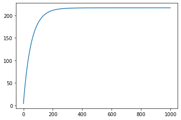

```python
iter=np.arange(0, 1000, 1);
plt.plot(iter,Error)
```

```python
print("Actual x is suppose to equal " + str(xf))
print(" ")
print("x that we attained instead x =" + str(x))
```

```
Actual x is suppose to equal [ 0.01527918  0.01117073  0.02786174  0.00306906  0.01345888 -0.00040408
  0.00600128  0.01674118  0.02055921  0.00582511  0.00675385  0.00123288
  0.00699967 -0.00230407  0.02304208  0.00774381  0.002984    0.01718957
  0.02333858  0.02042013  0.02288018  0.00370679  0.01633912  0.01183984
  0.01356707 -0.00085474  0.02079758  0.00528755  0.00406749  0.00407551
  0.00736389  0.02712871  0.01524454  0.02081967  0.00998565  0.01969101
 -0.00195039 -0.000518   -0.0028908   0.01894643  0.00776902  0.01752591
  0.0055765   0.00835817 -0.00554107  0.00261627 -0.00125191 -0.0011349
 -0.00526933 -0.00101309]

x that we attained instead x =[31.8431253  26.06352473 36.55015983 17.92366432 38.55500538 23.25470045
 23.65933676 28.77868044 45.31772375 28.47156643 29.40883432 20.95403498
 29.07408623 20.3486329  41.13082222 26.43573664 27.76996541 37.33184348
 42.471592   43.35784698 33.67377028 20.54580419 49.13817896 29.4520363
 23.70564249 20.72653182 34.95536157 24.38465858 20.35253448 23.83706275
 23.80517904 34.75134503 48.96037276 31.74453845 25.02967215 48.02035974
 20.37063302 21.34396681 14.3593056  47.58451721 24.72967115 43.1586872
 24.45483631 31.54188565 15.42528    29.53753294 14.56421175 20.64048098
 14.44291732 23.3458541 ]
```

With our chosen $x_{0}$, Richardson iteration failed to converge, and partially diverged from the expected solution as it is shown up. Unfortunately we were able to chose an optimal $x_{0}$ which would lead to Richardson iteration convering to $\text{xf}$.

Jacobi iterative scheme is constructed when $\text{M}$ is chosen to be the diagonal element of matrix $\text{A}$, and is thus denoted as $\text{D}$, e.g., $\text{diag(A)}$. The following is how to derive the Jacobi iterative:

$$Ax=b \to (M-N)x=b \to Mx=Nx+b \to Mx^{(k+1)}=(M-A)x^{(k)}+b$$

$$\to Dx^{(k+1)}=(D-A)x^{(k)}+b \to D^{-1}Dx^{(k+1)}=D^{-1}(D-A)x^{(k)}+D^{-1}b \to x^{(k+1)}=(I-D^{-1}A)x^{(k)}+D^{-1}b$$

$$\to x^{(k+1)}=x^{(k)}-D^{-1}Ax^{(k)}+D^{-1}b \to x^{(k+1)}=x^{(k)}+D^{-1}b-D^{-1}Ax^{(k)} \to x^{(k+1)}=x^{(k)}+D^{-1}(b-Ax^{(k)})$$

$$\to x^{(k+1)}=x^{(k)}+D^{-1}r^{k}$$

Convergence of Jacobi method is dependent upon the magnitude of the diagonal elements of matrix $\text{A}$, the large these diagonal elements the faster the convergence rate of Jacobi method. Nevertheless we developed a python function named, Jacobi, for the Jacobi iterative scheme.

```python
def Jacobi(A):
    iterMax=1000;
    r=b-A@x0;
    r0=LA.norm(r);
    error_vec=np.zeros(iterMax);
    error=r0;
    x=x0;
    xf=np.linalg.solve(A,b);
    Error=np.zeros(iterMax);

    D=np.diag(np.diag(A));

    for i in range(iterMax):
        r=b-A@x;
        x=x+np.linalg.solve(D,r);
        error_vec[i]=LA.norm(r);
        error=LA.norm(r);
        Error[i]=np.abs(LA.norm(xf-x));
        print("Error =" + " " + str(Error[i]))

        if Error[i] < tol:
            print("iteration =" + " " + str(i))
            break;

    return x,Error,error,xf;
```

To test the Jacobi iterative scheme, we chose to utilize the same construction that was provided for the test of Richardson iteration. Though to reiterate the terms of accuracy, we chose a tolerance of $10^{-15}$, and allowed the Jacobi iterative 1000 iterations to achieve this degree of accuracy.

```python
[x,Error,error,xf]=Jacobi(A);
```

```
Error = 0.055530424606187095
Error = 0.045246526187104584
Error = 0.037007604123152245
Error = 0.030271880300521137
Error = 0.024761828435654817
Error = 0.020254717449815277
Error = 0.016567986548050844
Error = 0.013552308324125333
Error = 0.011085538984675236
Error = 0.009067767029239516
Error = 0.007417266676012325
Error = 0.006067187739344964
Error = 0.004962847996756981
Error = 0.004059518395844774
Error = 0.0033206113942983867
Error = 0.0027161990553437737
Error = 0.0022218008770668813
Error = 0.001817392259092134
Error = 0.0014865934465596135
Error = 0.0012160061012133642
Error = 0.0009946706287520533
Error = 0.0008136222825812973
Error = 0.0006655280648463043
Error = 0.0005443897181537657
Error = 0.0004453007782624218
Error = 0.0003642478476514959
Error = 0.0002979480409543854
Error = 0.00024371601831258964
Error = 0.0001993552211045988
Error = 0.000163068904772143
Error = 0.00013338736530825964
Error = 0.00010910841186269521
Error = 8.924867442796365e-05
Error = 7.300377442182393e-05
Error = 5.9715744956361714e-05
Error = 4.8846381217057866e-05
Error = 3.9955441563131274e-05
Error = 3.268281642830867e-05
Error = 2.673394280974413e-05
Error = 2.1867873588011523e-05
```

[output cut: 105 more lines]

```
Error = 1.2316128442516198e-14
Error = 1.0078918977994244e-14
Error = 8.242036869394424e-15
Error = 6.74660199589346e-15
Error = 5.513342819414502e-15
Error = 4.5157078302676934e-15
Error = 3.689360279612099e-15
Error = 3.022738633545345e-15
Error = 2.4686997321218435e-15
Error = 2.0223322564986415e-15
Error = 1.6506993208627507e-15
Error = 1.3572685177120341e-15
Error = 1.103429874688794e-15
Error = 9.08849788083937e-16
iteration = 158
```

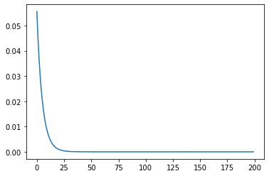

```python
iter=np.arange(0, 200, 1);
e=np.zeros(200);
for i in range(200):
    e[i]=Error[i]

plt.plot(iter,e)
```

```python
print("Actual x is suppose to equal ")
print("xf =")
print(xf)
print(" ")
print("x that we attained")
print("x =")
print(x)
```

```
Actual x is suppose to equal
xf =
[ 0.01527918  0.01117073  0.02786174  0.00306906  0.01345888 -0.00040408
  0.00600128  0.01674118  0.02055921  0.00582511  0.00675385  0.00123288
  0.00699967 -0.00230407  0.02304208  0.00774381  0.002984    0.01718957
  0.02333858  0.02042013  0.02288018  0.00370679  0.01633912  0.01183984
  0.01356707 -0.00085474  0.02079758  0.00528755  0.00406749  0.00407551
  0.00736389  0.02712871  0.01524454  0.02081967  0.00998565  0.01969101
 -0.00195039 -0.000518   -0.0028908   0.01894643  0.00776902  0.01752591
  0.0055765   0.00835817 -0.00554107  0.00261627 -0.00125191 -0.0011349
 -0.00526933 -0.00101309]

x that we attained
x =
[ 0.01527918  0.01117073  0.02786174  0.00306906  0.01345888 -0.00040408
  0.00600128  0.01674118  0.02055921  0.00582511  0.00675385  0.00123288
  0.00699967 -0.00230407  0.02304208  0.00774381  0.002984    0.01718957
  0.02333858  0.02042013  0.02288018  0.00370679  0.01633912  0.01183984
  0.01356707 -0.00085474  0.02079758  0.00528755  0.00406749  0.00407551
  0.00736389  0.02712871  0.01524454  0.02081967  0.00998565  0.01969101
 -0.00195039 -0.000518   -0.0028908   0.01894643  0.00776902  0.01752591
  0.0055765   0.00835817 -0.00554107  0.00261627 -0.00125191 -0.0011349
 -0.00526933 -0.00101309]
```

Our Jacobi iterative scheme was successful in converging to the true x value $\text{xf}$. It took our iterative scheme a total of 158 iterations to achieve an arrucary of $10^{-16}$, or in other words, machine epsilon, $\epsilon$.

Forward Gauss-seidel is contructed when matrix $\text{M}$ is chosen as the lower triangular of matrix $\text{A}$ including the diagonal elements denoted as $\text{D}$. In simple terms, $\text{M}=\text{tril(A)}=\text{D}-\text{E}$, where matrix $\text{F}$ represents the upper triangular region of matrix $\text{A}$, minus the diagonal elements.

$$Ax=b \to (M-N)x=b \to Mx=Nx+b \to Mx^{(k+1)}=(M-A)x^{(k)}+b$$

$$\to (D-E)x^{(k+1)}=(M-A)x^{(k)}+b \to (D-E)x^{(k+1)}=Fx^{(k)}+b.$$

We created a python function named $\text{Foward_GS()}$ for the Forward Gauss-Seidel iterative scheme, we parsed matrix $\text{A}$ into lower triangular matrix $\text{S}$, which includes the diagonal elements denoted in $\text{A}$, and an upper triangular matrix $\text{T}$.

```python
def Foward_GS(A):
    iterMax=1000;
    r=b-A@x0;
    r0=LA.norm(r);
    error_vec=np.zeros(iterMax);
    error=r0;
    x=x0;
    xf=np.linalg.solve(A,b);
    Error=np.zeros(iterMax);

    S=np.tril(A);
    T=S-A;

    for i in range(iterMax):
        r=b+T@x;
        x=np.linalg.solve(S,r);
        error_vec[i]=LA.norm(r);
        error=LA.norm(r);
        Error[i]=np.abs(LA.norm(xf-x));
        print("Error =" + " " + str(Error[i]))

        if Error[i] < tol:
            print("iteration =" + " " + str(i))
            break;

    return x,Error,error,xf;
```

To test the Forward Gauss-Seidel scheme, we chose to utilize the same construction that was provided for the test of Richardson and Jacobi iterations. Though to reiterate the terms of accuracy, we chose a tolerance of $10^{-15}$, and allowed the Jacobi iterative 1000 iterations to achieve this degree of accuracy.

```python
[x,Error,error,xf]=Foward_GS(A);
```

```
Error = 0.025455885892669207
Error = 0.0034120419296820408
Error = 0.0007124917627601864
Error = 0.00013452048801078386
Error = 2.1802663359767737e-05
Error = 5.069194831280529e-06
Error = 6.78007469656253e-07
Error = 1.8285662884846304e-07
Error = 2.254252617980836e-08
Error = 6.307431166829303e-09
Error = 8.244788793400598e-10
Error = 2.0814302559925094e-10
Error = 3.192961224949023e-11
Error = 6.59664841285483e-12
Error = 1.2390267612762135e-12
Error = 2.034159782213323e-13
Error = 4.6705073114703e-14
Error = 6.313726092388021e-15
Error = 1.6816469800373744e-15
Error = 2.1080194448331971e-16
iteration = 19
```

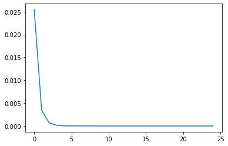

```python
iter=np.arange(0, 25, 1);
e=np.zeros(25);
for i in range(25):
    e[i]=Error[i]

plt.plot(iter,e)
```

```python
print("Actual x is suppose to equal ")
print("xf =")
print(xf)
print(" ")
print("x that we attained")
print("x =")
print(x)
```

```
Actual x is suppose to equal
xf =
[ 0.01527918  0.01117073  0.02786174  0.00306906  0.01345888 -0.00040408
  0.00600128  0.01674118  0.02055921  0.00582511  0.00675385  0.00123288
  0.00699967 -0.00230407  0.02304208  0.00774381  0.002984    0.01718957
  0.02333858  0.02042013  0.02288018  0.00370679  0.01633912  0.01183984
  0.01356707 -0.00085474  0.02079758  0.00528755  0.00406749  0.00407551
  0.00736389  0.02712871  0.01524454  0.02081967  0.00998565  0.01969101
 -0.00195039 -0.000518   -0.0028908   0.01894643  0.00776902  0.01752591
  0.0055765   0.00835817 -0.00554107  0.00261627 -0.00125191 -0.0011349
 -0.00526933 -0.00101309]

x that we attained
x =
[ 0.01527918  0.01117073  0.02786174  0.00306906  0.01345888 -0.00040408
  0.00600128  0.01674118  0.02055921  0.00582511  0.00675385  0.00123288
  0.00699967 -0.00230407  0.02304208  0.00774381  0.002984    0.01718957
  0.02333858  0.02042013  0.02288018  0.00370679  0.01633912  0.01183984
  0.01356707 -0.00085474  0.02079758  0.00528755  0.00406749  0.00407551
  0.00736389  0.02712871  0.01524454  0.02081967  0.00998565  0.01969101
 -0.00195039 -0.000518   -0.0028908   0.01894643  0.00776902  0.01752591
  0.0055765   0.00835817 -0.00554107  0.00261627 -0.00125191 -0.0011349
 -0.00526933 -0.00101309]
```

Our Forward Gauss-Seidel iterative scheme successfully converged to actual x value $\text{xf}$. It took our iterative scheme a total of 19 iterations to achieve an arrucary of $10^{-16}$, or in other words, machine epsilon, $\epsilon$.

Backward Gauss-seidel is contructed when matrix $\text{M}$ is chosen as the upper triangular of matrix $\text{A}$ including the diagonal elements denoted as $\text{D}$. In simple terms, $\text{M}=\text{triu(A)}=\text{D}-\text{F}$, where matrix $\text{E}$ represents the lower triangular region of matrix $\text{A}$, minus the diagonal elements.

$$Ax=b \to (M-N)x=b \to Mx=Nx+b \to Mx^{(k+1)}=(M-A)x^{(k)}+b$$

$$\to (D-F)x^{(k+1)}=(M-A)x^{(k)}+b \to (D-E)x^{(k+1)}=Ex^{(k)}+b.$$

We created a python function named $\text{Backward_GS()}$ for the Backward Gauss-Seidel iterative scheme, we parsed matrix $\text{A}$ into upper triangular matrix $\text{T}$, which includes the diagonal elements denoted in $\text{A}$, and an lower triangular matrix $\text{S}$.

```python
def Backward_GS(A):
    iterMax=1000;
    r=b-A*x0;
    r0=LA.norm(r);
    error_vec=np.zeros(iterMax);
    error=r0;
    x=x0;
    xf=np.linalg.solve(A,b);
    Error=np.zeros(iterMax);

    D=np.diag(np.diag(A));
    T=np.triu(A);
    S=T-A;

    for i in range(iterMax):
        r=b+S@x;
        x=np.linalg.solve(T,r);
        error_vec[i]=LA.norm(r);
        error=LA.norm(r);
        Error[i]=np.abs(LA.norm(xf-x));
        print("Error =" + " " + str(Error[i]))

        if Error[i] < tol:
            print("iteration =" + " " + str(i))
            break;

    return x,Error,error,xf;
```

To test the Backward Gauss-Seidel scheme, we chose to utilize the same construction that was provided for the test of Richardson, Jacobi, Forward Gauss-Seidel iterations. Though to reiterate the terms of accuracy, we chose a tolerance of $10^{-15}$, and allowed the Jacobi iterative 1000 iterations to achieve this degree of accuracy.

```python
[x,Error,error,xf]=Backward_GS(A);
```

```
Error = 0.030061447523344005
Error = 0.005227119117800962
Error = 0.0005959749639621846
Error = 0.00014299979088126317
Error = 1.6060741779552484e-05
Error = 4.027974210636372e-06
Error = 4.5815018862480565e-07
Error = 1.1166664073250691e-07
Error = 1.3693082859270454e-08
Error = 3.027890775752055e-09
Error = 4.1965779789846607e-10
Error = 8.036617270368099e-11
Error = 1.2899211859450837e-11
Error = 2.0974427380342342e-12
Error = 3.9189185696452837e-13
Error = 5.4374823415043996e-14
Error = 1.1675630865029725e-14
Error = 1.4129478369526836e-15
Error = 3.461452125638949e-16
iteration = 18
```

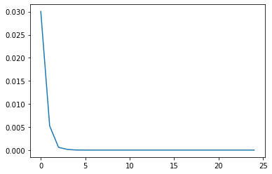

```python
iter=np.arange(0, 25, 1);
e=np.zeros(25);
for i in range(25):
    e[i]=Error[i]

plt.plot(iter,e)
```

```python
print("Actual x is suppose to equal ")
print("xf =")
print(xf)
print(" ")
print("x that we attained")
print("x =")
print(x)
```

```
Actual x is suppose to equal
xf =
[ 0.01527918  0.01117073  0.02786174  0.00306906  0.01345888 -0.00040408
  0.00600128  0.01674118  0.02055921  0.00582511  0.00675385  0.00123288
  0.00699967 -0.00230407  0.02304208  0.00774381  0.002984    0.01718957
  0.02333858  0.02042013  0.02288018  0.00370679  0.01633912  0.01183984
  0.01356707 -0.00085474  0.02079758  0.00528755  0.00406749  0.00407551
  0.00736389  0.02712871  0.01524454  0.02081967  0.00998565  0.01969101
 -0.00195039 -0.000518   -0.0028908   0.01894643  0.00776902  0.01752591
  0.0055765   0.00835817 -0.00554107  0.00261627 -0.00125191 -0.0011349
 -0.00526933 -0.00101309]

x that we attained
x =
[ 0.01527918  0.01117073  0.02786174  0.00306906  0.01345888 -0.00040408
  0.00600128  0.01674118  0.02055921  0.00582511  0.00675385  0.00123288
  0.00699967 -0.00230407  0.02304208  0.00774381  0.002984    0.01718957
  0.02333858  0.02042013  0.02288018  0.00370679  0.01633912  0.01183984
  0.01356707 -0.00085474  0.02079758  0.00528755  0.00406749  0.00407551
  0.00736389  0.02712871  0.01524454  0.02081967  0.00998565  0.01969101
 -0.00195039 -0.000518   -0.0028908   0.01894643  0.00776902  0.01752591
  0.0055765   0.00835817 -0.00554107  0.00261627 -0.00125191 -0.0011349
 -0.00526933 -0.00101309]
```

Our Backward Gauss-Seidel iterative scheme successfully converged to actual x value $\text{xf}$. It took our iterative scheme a total of 18 iterations to achieve an arrucary of $10^{-16}$, or in other words, machine epsilon, $\epsilon$.

Symmetric Gauss-seidel is departure from the previous to scheme, instead of choosing a single matrix $\text{M}$, we parse the iteration itself between Forward Gauss-Seidel and Backward Gauss-Seidel and form a whole iteration through these two schemes.

$$(D-E)x^{(k+1/2)}=Fx^{(k)}+b$$

$$(D-F)x^{(k+1)}=Ex^{(k+1/2)}+b$$

We created a python function named $\text{Symmetric_GS()}$ for the Symmetric Gauss-Seidel iterative scheme, we incorportated the parsed matrice from Forward Gauss-Seidel and Backward Gauss-Seidel. In other words, $\text{A}$ was parsed into lower triangular matrix $\text{S}$ which includes the diagonal elements found in $\text{D}$, and upper triangular matrix $\text{T}$. Also matrix $\text{A}$ was parsed into upper triangular matrix $\text{F}$ which also contains the diagonal elements fround in matrix $\text{D}$, and lower triangular matrix $\text{S}$. Following for each scheme we calculate the residual, then implicitly calculating the inverse of matrix $\text{M}$ in each portion of the parsed iteration.

```python
def Symmetrix_GS(A):
    iterMax=1000;
    r=b-A@x0;
    r0=LA.norm(r);
    error_vec=np.zeros(iterMax);
    error=r0;
    x=x0;
    xf=np.linalg.solve(A,b);
    Error=np.zeros(iterMax);

    D=np.diag(np.diag(A));
    S=np.tril(A);
    T=S-A;

    F=np.triu(A);
    E=F-A;

    for i in range(iterMax):
        r=b+T@x;
        x=np.linalg.solve(S,r);
        s=b+E@x;
        x=np.linalg.solve(F,s);
        error_vec[i]=LA.norm(r);
        error=LA.norm(r);
        Error[i]=np.abs(LA.norm(xf-x));
        print("Error =" + " " + str(Error[i]))

        if Error[i] < tol:
            print("iteration =" + " " + str(i))
            break;

    return x,Error,error,xf;
```

To test the Symmetric Gauss-Seidel scheme, we chose to utilize the same construction that was provided for the test of Richardson, Jacobi, Forward Gauss-Seidel and Backward Gauss-Seidel iterations. Though to reiterate the terms of accuracy, we chose a tolerance of $10^{-15}$, and allowed the Jacobi iterative 1000 iterations to achieve this degree of accuracy.

```python
[x,Error,error,xf]=Symmetrix_GS(A);
```

```
Error = 0.008589817208059737
Error = 0.0013287925733064697
Error = 0.0002037855190804313
Error = 3.110791058938237e-05
Error = 4.743802258687129e-06
Error = 7.232564439305526e-07
Error = 1.1026558592310705e-07
Error = 1.6810632554916525e-08
Error = 2.5628748380518733e-09
Error = 3.9072444922059945e-10
Error = 5.956809278004272e-11
Error = 9.08147646414499e-12
Error = 1.384515262585774e-12
Error = 2.1106492552477204e-13
Error = 3.217546488721012e-14
Error = 4.899612584696605e-15
Error = 7.414137300725812e-16
iteration = 16
```

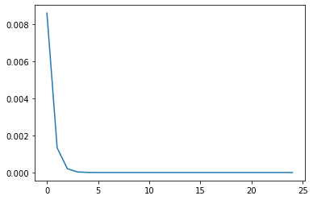

```python
iter=np.arange(0, 25, 1);
e=np.zeros(25);
for i in range(25):
    e[i]=Error[i]

plt.plot(iter,e)
```

```python
print("Actual x is suppose to equal ")
print("xf =")
print(xf)
print(" ")
print("x that we attained")
print("x =")
print(x)
```

```
Actual x is suppose to equal
xf =
[ 0.01527918  0.01117073  0.02786174  0.00306906  0.01345888 -0.00040408
  0.00600128  0.01674118  0.02055921  0.00582511  0.00675385  0.00123288
  0.00699967 -0.00230407  0.02304208  0.00774381  0.002984    0.01718957
  0.02333858  0.02042013  0.02288018  0.00370679  0.01633912  0.01183984
  0.01356707 -0.00085474  0.02079758  0.00528755  0.00406749  0.00407551
  0.00736389  0.02712871  0.01524454  0.02081967  0.00998565  0.01969101
 -0.00195039 -0.000518   -0.0028908   0.01894643  0.00776902  0.01752591
  0.0055765   0.00835817 -0.00554107  0.00261627 -0.00125191 -0.0011349
 -0.00526933 -0.00101309]

x that we attained
x =
[ 0.01527918  0.01117073  0.02786174  0.00306906  0.01345888 -0.00040408
  0.00600128  0.01674118  0.02055921  0.00582511  0.00675385  0.00123288
  0.00699967 -0.00230407  0.02304208  0.00774381  0.002984    0.01718957
  0.02333858  0.02042013  0.02288018  0.00370679  0.01633912  0.01183984
  0.01356707 -0.00085474  0.02079758  0.00528755  0.00406749  0.00407551
  0.00736389  0.02712871  0.01524454  0.02081967  0.00998565  0.01969101
 -0.00195039 -0.000518   -0.0028908   0.01894643  0.00776902  0.01752591
  0.0055765   0.00835817 -0.00554107  0.00261627 -0.00125191 -0.0011349
 -0.00526933 -0.00101309]
```

Our Symmetric Gauss-Seidel iterative scheme successfully converged to actual x value $\text{xf}$. It took our iterative scheme a total of 16 iterations to achieve an arrucary of $10^{-16}$, or in other words, machine epsilon, $\epsilon$.

A variation of Gauss-Seidel, successive over-relation (SOR) is an iterative scheme meant to attain a faster convergence rate than normal Gauss-seidel, while possessing applicability to solve less than optimitally conditioned matrices. In consequence Forward SOR is derived in similar fashion to Gauss-Seidel, though the parsing of matrix $\text{A}$ is quite different.

$$\omega A = \omega (D-E-F)=(D-\omega E)-(\omega F + (1+\omega)D) = M - N$$

When $\omega = 1$, the this iterative scheme become the normal Gauss-seidel iterative scheme, but when $\omega$ is between $0 < \omega > 1$ the iterative scheme becomes relaxed, while when $\omega$ is between $1 < \omega < 2$ the iterative scheme become over-relaxed. In conception the practitioner tries to fit an optimal $\omega$ to the iterative scheme to cause of relaxation or over-relaxation in the system, so that the scheme can achieve a faster convergence rate than Gauss-Seidel. Though similarly Gauss-Seidel, successive over-relaxation requires that the matrix $\text{A}$ possess only real eigenvalues and a spectral radius below 1 for the SOR iterative scheme to converge.

In the same fashion as the previous algorithms, we created an python function named in the name of the iterative scheme, as such, we composed $\text{Forward_SOR()}$ and named it as such.

```python
def Forward_SOR(A,w):
    iterMax=1000;
    r=b-A@x0;
    r0=LA.norm(r);
    error_vec=np.zeros(iterMax);
    error=r0;
    x=x0;
    xf=np.linalg.solve(A,b);
    Error=np.zeros(iterMax);

    D=np.diag(np.diag(A));
    S=np.tril(A);

    for i in range(iterMax):
        r=b-A@x;
        x=x+np.linalg.solve(S,r);
        error_vec[i]=LA.norm(r);
        error=LA.norm(r);
        Error[i]=np.abs(LA.norm(xf-x));
        print("Error =" + " " + str(Error[i]))

        if Error[i] < tol:
            print("iteration =" + " " + str(i))
            break;

    return x,Error,error,xf;
```

```python
w=0.8;
b=(w)*np.random.random(m);
x0=np.random.random(m);
iterMax=1000;
tol=10**-15;
```

```python
[x,Error,error,xf]=Forward_SOR(A,w);
```

```
Error = 1.4957405962631536
Error = 0.24862669579136737
Error = 0.03664096119124207
Error = 0.009103745337677875
Error = 0.001157304595881534
Error = 0.0003224365618359346
Error = 4.002768686103524e-05
Error = 1.0924883024905636e-05
Error = 1.509024840240661e-06
Error = 3.544757175679369e-07
Error = 5.881343533210359e-08
Error = 1.1085559462770914e-08
Error = 2.2611491070591746e-09
Error = 3.4078091843822825e-10
Error = 8.389868359407697e-11
Error = 1.0764017674302506e-11
Error = 2.982157823112152e-12
Error = 3.692582917121036e-13
Error = 1.0136557467513832e-13
Error = 1.385964212344325e-14
Error = 3.298998102412665e-15
Error = 5.365639874833079e-16
iteration = 21
```

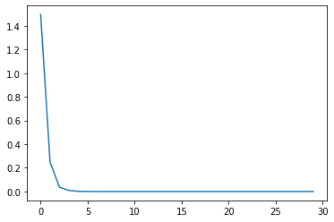

```python
iter=np.arange(0, 30, 1);
e=np.zeros(30);
for i in range(30):
    e[i]=Error[i]

plt.plot(iter,e)
```

```python
print("Actual x is suppose to equal ")
print("xf =")
print(xf)
print(" ")
print("x that we attained")
print("x =")
print(x)
```

```
Actual x is suppose to equal
xf =
[ 0.01653719  0.00764323 -0.00063941  0.0118665   0.00476055  0.004278
  0.01071593  0.00125539  0.01621563  0.01200302  0.00868893  0.00692096
  0.01377281  0.00329592  0.01871948  0.00590853  0.00858734  0.01607569
  0.01774752  0.00782082  0.01660217  0.02343015 -0.00425364  0.00069133
 -0.00728745  0.00950591  0.00232232  0.01851946  0.00152364  0.00976238
  0.01289462  0.01443115 -0.00501602  0.02033975 -0.00573622  0.01077661
 -0.00528822  0.00369776  0.01060101 -0.00318158  0.0139898   0.0164442
 -0.00188479  0.00907338  0.00707072  0.00348689  0.01105011  0.00655638
 -0.00249146  0.0094628 ]

x that we attained
x =
[ 0.01653719  0.00764323 -0.00063941  0.0118665   0.00476055  0.004278
  0.01071593  0.00125539  0.01621563  0.01200302  0.00868893  0.00692096
  0.01377281  0.00329592  0.01871948  0.00590853  0.00858734  0.01607569
  0.01774752  0.00782082  0.01660217  0.02343015 -0.00425364  0.00069133
 -0.00728745  0.00950591  0.00232232  0.01851946  0.00152364  0.00976238
  0.01289462  0.01443115 -0.00501602  0.02033975 -0.00573622  0.01077661
 -0.00528822  0.00369776  0.01060101 -0.00318158  0.0139898   0.0164442
 -0.00188479  0.00907338  0.00707072  0.00348689  0.01105011  0.00655638
 -0.00249146  0.0094628 ]
```

Our Forward SOR iterative scheme successfully converged to actual x value $\text{xf}$. It took our iterative scheme a total of 21 iterations to achieve an arrucary of $10^{-16}$, or in other words, machine epsilon, $\epsilon$.

Backward successive over-relaxation (SOR) is paradigm of the SOR and Backward Gauss-Seidel, where the parsing of matrix $\text{A}$ is in similar fashion to Backward Gauss-Seidel - though the parsement are perturbed by an omega parameter, $\omega$, which deviate the scheme slightly.

$$\omega A = \omega (D-E-F)=(D-\omega F-(\omega E+ (1+\omega)D) = M - N$$

Which practically make the scheme almost identical to Forward SOR, except the backward system is solving the upper triangular matrix $\text{T}$ instead of the lower triangular matrix $\text{S}$.

Nonetheless we composed an python function named, $\text{Backward_SOR()}$ with the slight modification to the algorithm which transform the scheme from Forward to Backward.

```python
def Backward_SOR(A,w):
    iterMax=1000;
    r=b-A@x0;
    r0=LA.norm(r);
    error_vec=np.zeros(iterMax);
    error=r0;
    x=x0;
    xf=np.linalg.solve(A,b);
    Error=np.zeros(iterMax);

    D=np.diag(np.diag(A));
    T=np.triu(A);

    for i in range(iterMax):
        r=b-A@x;
        x=x+np.linalg.solve(T,r);
        error_vec[i]=LA.norm(r);
        error=LA.norm(r);
        Error[i]=np.abs(LA.norm(xf-x));
        print("Error =" + " " + str(Error[i]))

        if Error[i] < tol:
            print("iteration =" + " " + str(i))
            break;

    return x,Error,error,xf;
```

```python
[x,Error,error,xf]=Backward_SOR(A,w);
```

```
Error = 1.565678303791333
Error = 0.2580513417475725
Error = 0.02958419491763997
Error = 0.007016563569688269
Error = 0.0007911082079729509
Error = 0.00019813241571920324
Error = 2.2430117071288072e-05
Error = 5.508719187615124e-06
Error = 6.673012733477619e-07
Error = 1.4979273387191214e-07
Error = 2.0415360485906346e-08
Error = 3.9856426881613195e-09
Error = 6.278935882625637e-10
Error = 1.0419381790827846e-10
Error = 1.9113350875933724e-11
Error = 2.7009193547850542e-12
Error = 5.710985998766886e-13
Error = 7.059729670122303e-14
Error = 1.6688171281339404e-14
Error = 1.910775700478263e-15
Error = 4.753282917200953e-16
iteration = 20
```

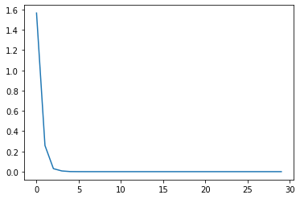

```python
iter=np.arange(0, 30, 1);
e=np.zeros(30);
for i in range(30):
    e[i]=Error[i]

plt.plot(iter,e)
```

```python
print("Actual x is suppose to equal ")
print("xf =")
print(xf)
print(" ")
print("x that we attained")
print("x =")
print(x)
```

```
Actual x is suppose to equal
xf =
[ 0.01653719  0.00764323 -0.00063941  0.0118665   0.00476055  0.004278
  0.01071593  0.00125539  0.01621563  0.01200302  0.00868893  0.00692096
  0.01377281  0.00329592  0.01871948  0.00590853  0.00858734  0.01607569
  0.01774752  0.00782082  0.01660217  0.02343015 -0.00425364  0.00069133
 -0.00728745  0.00950591  0.00232232  0.01851946  0.00152364  0.00976238
  0.01289462  0.01443115 -0.00501602  0.02033975 -0.00573622  0.01077661
 -0.00528822  0.00369776  0.01060101 -0.00318158  0.0139898   0.0164442
 -0.00188479  0.00907338  0.00707072  0.00348689  0.01105011  0.00655638
 -0.00249146  0.0094628 ]

x that we attained
x =
[ 0.01653719  0.00764323 -0.00063941  0.0118665   0.00476055  0.004278
  0.01071593  0.00125539  0.01621563  0.01200302  0.00868893  0.00692096
  0.01377281  0.00329592  0.01871948  0.00590853  0.00858734  0.01607569
  0.01774752  0.00782082  0.01660217  0.02343015 -0.00425364  0.00069133
 -0.00728745  0.00950591  0.00232232  0.01851946  0.00152364  0.00976238
  0.01289462  0.01443115 -0.00501602  0.02033975 -0.00573622  0.01077661
 -0.00528822  0.00369776  0.01060101 -0.00318158  0.0139898   0.0164442
 -0.00188479  0.00907338  0.00707072  0.00348689  0.01105011  0.00655638
 -0.00249146  0.0094628 ]
```

Our Backward SOR iterative scheme successfully converged to actual x value $\text{xf}$. It took our iterative scheme a total of 20 iterations to achieve an arrucary of $10^{-16}$, or in other words, machine epsilon, $\epsilon$.

Symmetric SOR is a paradigm of Symmetric Gauss-seidel, though of course there exists an omega, $\omega$ which perturbates the parsed matrices of matrix $\text{A}$. Yet again due to the paradigm relationship between the two iterative schemes, after a derivation to form Forward SOR and Backward SOR, we attain a similar parsed iterative structure to Symmetric Gauss-Seidel.

$$(D-\omega E)x^{(k+1/2)}=(\omega F+ (1-\omega)D)x^{(k)}+\omega b$$

$$(D-\omega F)x^{(k+1)}=(\omega E+(1-\omega)D)x^{(k+1/2)}+\omega b$$

We composed symmetric SOR, and named it $\text{symmetric_SOR}$.

```python
def Symmetric_SOR(A,w):
    iteration=0;
    r=b-A@x0;
    r0=LA.norm(r);
    error_vec=np.zeros(iterMax);
    error=r0;
    x=x0;
    xf=np.linalg.solve(A,b);
    Error=np.zeros(iterMax);

    D=np.diag(np.diag(A));
    S=np.tril(A);
    S=S-D; S=(w)*S; S=S+D;
    F=np.triu(A); F=(w)*F; F=F+D;

    for i in range(iterMax):
        iteration = iteration + 1;
        r=b-A@x;
        x=x+np.linalg.solve(S,r);
        s=b-A@x;
        x=x+np.linalg.solve(F,s);
        error_vec[i]=LA.norm(r);
        error=LA.norm(r);
        Error[i]=np.abs(LA.norm(xf-x));
        print("Error =" + " " + str(Error[i]))

        if Error[i] < tol:
            print("iteration =" + " " + str(i))
            break;

    return x,Error,error,xf;
```

To test the Symmetric SOR scheme, we continued with the established test construction that was utilized in previous tests, and $\omega$ parameter destinated in the first test concerning Forward SOR (Note: $\omega = 0.8$).

```python
[x,Error,error,xf]=Symmetric_SOR(A,w);
```

```
Error = 0.6141452596518285
Error = 0.026819407318358912
Error = 0.0021562757617249123
Error = 0.0001280492103690126
Error = 8.873377444263513e-06
Error = 6.519695914210065e-07
Error = 3.642278356103747e-08
Error = 3.054726393304929e-09
Error = 1.719942413465887e-10
Error = 1.2868353399909914e-11
Error = 8.833842063975992e-13
Error = 5.195918439983953e-14
Error = 4.277876889646238e-15
Error = 2.3556642016505815e-16
iteration = 13
```

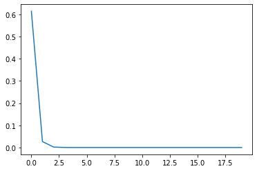

```python
iter=np.arange(0, 20, 1);
e=np.zeros(20);
for i in range(20):
    e[i]=Error[i]

plt.plot(iter,e)
```

```python
print("Actual x is suppose to equal ")
print("xf =")
print(xf)
print(" ")
print("x that we attained")
print("x =")
print(x)
```

```
Actual x is suppose to equal
xf =
[ 0.01653719  0.00764323 -0.00063941  0.0118665   0.00476055  0.004278
  0.01071593  0.00125539  0.01621563  0.01200302  0.00868893  0.00692096
  0.01377281  0.00329592  0.01871948  0.00590853  0.00858734  0.01607569
  0.01774752  0.00782082  0.01660217  0.02343015 -0.00425364  0.00069133
 -0.00728745  0.00950591  0.00232232  0.01851946  0.00152364  0.00976238
  0.01289462  0.01443115 -0.00501602  0.02033975 -0.00573622  0.01077661
 -0.00528822  0.00369776  0.01060101 -0.00318158  0.0139898   0.0164442
 -0.00188479  0.00907338  0.00707072  0.00348689  0.01105011  0.00655638
 -0.00249146  0.0094628 ]

x that we attained
x =
[ 0.01653719  0.00764323 -0.00063941  0.0118665   0.00476055  0.004278
  0.01071593  0.00125539  0.01621563  0.01200302  0.00868893  0.00692096
  0.01377281  0.00329592  0.01871948  0.00590853  0.00858734  0.01607569
  0.01774752  0.00782082  0.01660217  0.02343015 -0.00425364  0.00069133
 -0.00728745  0.00950591  0.00232232  0.01851946  0.00152364  0.00976238
  0.01289462  0.01443115 -0.00501602  0.02033975 -0.00573622  0.01077661
 -0.00528822  0.00369776  0.01060101 -0.00318158  0.0139898   0.0164442
 -0.00188479  0.00907338  0.00707072  0.00348689  0.01105011  0.00655638
 -0.00249146  0.0094628 ]
```

Our Symmetric SOR iterative scheme successfully converged to actual x value $\text{xf}$. It took our iterative scheme a total of 13 iterations to achieve an arrucary of $10^{-16}$, or in other words, machine epsilon, $\epsilon$.

With this we will provide some comment and then conclude this section of the project, so that we may proceed to the last question.

Beside the difficulty in attaining an optimal initial condition to induce the Richardson iteration to converge, we did not experience any other difficults in deriving and coding of the other classical iterations (stationary iterations methods).

**C.4** (30 points) Implement the one-dimensional projection methods: Steepest decent, Residual norm steepest descent, and Minimy Residual iteration.

*Solution:*

The last objective for this project is to implement non-stationary iterative methods, also known as projection methods, as each of these scheme utlizes a non-orthogonal projection method to attain the solution of a linear system. The first of the projection methods will be Steepest Descent, like the others, a one-dimensional projection method with $K=L=\text{span}\{r\}$, which is the span of the residual provide by $r=b-Ax$ of the iterative's current iteration. For this projection scheme to converge it requires matrix $A$ to be symmetric positive definite (e.g. SPD), otherwise the project scheme will most probably diverge while iterating.

Instead of developing our own algorithm to Steepest Descent, we borrowed $\text{mysteepest()}$ written in MATLAB from Dr. Michael Rozman of the University of Connecticut, the source code can be found in a document that can be found [here](https://www.phys.uconn.edu/~rozman/Courses/m3511_18s/downloads/steepest-descent.pdf) . Nevertheless we translate the MATLAB into Python, and named the python function $\text{Steepest_Descent()}$.

```python
def Steepest_Descent(A,b,x,tol):
    iterMax=1000;
    r=b-A@x;
    delta=np.transpose(r)@r;
    converg=delta;
    delta0=delta;

    conv=np.zeros(iterMax);
    deltal=np.zeros(iterMax)

    for i in range(iterMax):
        q=A@r;
        alpha=delta/(np.transpose(q)@r);
        x=x+alpha*r;
        if np.remainder(i,50)==0:
            r=b-A@x;
        else:
            r=r-alpha*q;

        delta=np.transpose(r)@r;
        conv[i]=converg;
        deltal[i]=delta;
        print("convergence =" + " " + str(deltal[i]))

        if delta < (tol*delta0):
            print("iteration =" + " " + str(i))
            break;

    return x,conv;
```

```python
def SPD(n,m):
    a=n; b=m;
    A=np.random.random((a,b))
    n=A.shape[0];
    A=0.5*(A+np.transpose(A));
    A=A+10*np.eye(n);

    return A;
```

```python
n=50; m=50;
A=SPD(n,m);
b=np.random.random(m);
x=np.random.random(m);
iterMax=1000;
tol=10**-15;
```

```python
[x,converg]=Steepest_Descent(A,b,x,tol)
```

```
convergence = 212.92832991180262
convergence = 35.99891343493226
convergence = 2.3998204429034375
convergence = 1.2906615218176634
convergence = 0.10286990496985332
convergence = 0.06459084403603657
convergence = 0.005417349471751675
convergence = 0.0035939627767477508
convergence = 0.0003096670397963879
convergence = 0.00021183457428888104
convergence = 1.8549638317426004e-05
convergence = 1.2931395682924047e-05
convergence = 1.144387966749086e-06
convergence = 8.078807779660633e-07
convergence = 7.202085809260971e-08
convergence = 5.129373817126343e-08
convergence = 4.596916845739026e-09
convergence = 3.2949643343720292e-09
convergence = 2.96443413999448e-10
convergence = 2.134927694301274e-10
convergence = 1.9263658481611234e-11
convergence = 1.3922772925096857e-11
convergence = 1.259037611870073e-12
iteration = 22
```

```python
print("x =" + " " + str(x))
```

```
x = [ 0.04804307  0.05146562  0.02861344  0.01734807 -0.00948086  0.0560057
 -0.01176017 -0.01566727  0.02507163 -0.00776306  0.00164375 -0.02430442
 -0.01670205 -0.01403531  0.05076719  0.02135254  0.0182947  -0.0430725
 -0.04336336 -0.02817481 -0.01236506 -0.02682415  0.04593922  0.0605622
  0.02878682  0.00280396  0.03600876  0.05528001 -0.00668121 -0.01947653
  0.03014897 -0.00668174  0.01552247  0.02711621  0.02432741  0.02768906
  0.02022286  0.03023303  0.04253742  0.01449931  0.06064643  0.04981908
  0.0236062   0.04652898  0.06036131  0.05334948 -0.00112746  0.03206479
  0.03501804 -0.02689611]
```

```python
xf=np.linalg.solve(A,b);
```

```python
print("x =" + " " + str(x))
```

```
x = [ 0.04804307  0.05146562  0.02861344  0.01734807 -0.00948086  0.0560057
 -0.01176017 -0.01566727  0.02507163 -0.00776306  0.00164375 -0.02430442
 -0.01670205 -0.01403531  0.05076719  0.02135254  0.0182947  -0.0430725
 -0.04336336 -0.02817481 -0.01236506 -0.02682415  0.04593922  0.0605622
  0.02878682  0.00280396  0.03600876  0.05528001 -0.00668121 -0.01947653
  0.03014897 -0.00668174  0.01552247  0.02711621  0.02432741  0.02768906
  0.02022286  0.03023303  0.04253742  0.01449931  0.06064643  0.04981908
  0.0236062   0.04652898  0.06036131  0.05334948 -0.00112746  0.03206479
  0.03501804 -0.02689611]
```

Our Steepest Descent projection scheme successfully converged to the actual x value, $\text{xf}$. It took our projection scheme a total of 22 iterations to achieve an arrucary of $10^{-11}$.

The next projection is the Residual norm Steepest Descent method, which an projection method for non-singular matrices, which is a significantly boarden the quantity of matrices that this method is applicable towards. Nevertheless we extrapolated upon Steepest Descent to attain a functional RNSD scheme, and we named it, $\text{Residual Norm Steepest Descent}$.

```python
def Residual_Norm_Steepest_Descent(A,b,x,tol):
    iterMax=1000;
    r=b-A@x;

    for i in range(iterMax):
        v=np.transpose(A)@r;
        q=A@v;
        delta=np.transpose(v)@v;

        if i==0:
            delta0=delta;

        alpha=delta/(np.transpose(q)@q);
        x=x+alpha*v;
        if np.remainder(i,50)==0:
            r=b-A@x;
        else:
            r=r-alpha*q;

        delta=np.transpose(v)@v;
        conv=converg;
        deltal=delta;
        print("convergence =" + " " + str(deltal))

        if delta < (tol*delta0):
            print("iteration =" + " " + str(i))
            break;

    return x,converg;
```

To test $\text{Residual Norm Steepest Descent()}$, we generated a symmetric positive definite matrix $\text{A}$ through our function, $\text{SPD()}$. We then generated a solution vector $\text{b}$ of size $m$ x $1$, and an initial $x$ vector of the same size as $b$. In regards to accuracy and max iteration, we chose a tolerence of $10^{-15}$ and a max iteration of 1000.

```python
[x,converg]=Residual_Norm_Steepest_Descent(A,b,x,tol)
```

```
convergence = 2.628572810256216e-10
convergence = 6.695989074201767e-11
convergence = 1.6041645237776428e-10
convergence = 4.086943466881104e-11
convergence = 9.793083512103874e-11
convergence = 2.495289247951948e-11
convergence = 5.980303412385565e-11
convergence = 1.523959051764118e-11
convergence = 3.6530219828498246e-11
convergence = 9.309966751611826e-12
convergence = 2.2320260441878664e-11
convergence = 5.689029324044644e-12
convergence = 1.3641345257530258e-11
convergence = 3.4772559600081275e-12
convergence = 8.339108337699176e-12
convergence = 2.125872688418933e-12
convergence = 5.0989459671793905e-12
convergence = 1.2999720147930817e-12
convergence = 3.1184146867549523e-12
convergence = 7.950992323927781e-13
convergence = 1.9075442695224542e-12
convergence = 4.864004986340278e-13
convergence = 1.167072007071466e-12
convergence = 2.9760972715419983e-13
convergence = 7.141644401200823e-13
convergence = 1.8212772018480621e-13
convergence = 4.370910323391733e-13
convergence = 1.114747396649577e-13
convergence = 2.6755588409562143e-13
convergence = 6.824082942638899e-14
convergence = 1.6380310672720248e-13
convergence = 4.1780700278983625e-14
convergence = 1.0029772854497398e-13
convergence = 2.5583922088803676e-14
convergence = 6.142114856328017e-14
convergence = 1.5668056945820232e-14
convergence = 3.761831903914828e-14
convergence = 9.596582161761013e-15
convergence = 2.3042648239045306e-14
convergence = 5.878526285524582e-15
```

[output cut: 84 more lines]

```
convergence = 1.703963968284795e-23
convergence = 4.3405549983051464e-24
convergence = 1.0451531495298108e-23
convergence = 2.6623584045094732e-24
convergence = 6.4106774718050025e-24
convergence = 1.6330224502422317e-24
convergence = 3.93216889138522e-24
convergence = 1.001663733101169e-24
convergence = 2.411928480416741e-24
convergence = 6.144063460837835e-25
convergence = 1.4794507515191212e-24
convergence = 3.768714040359971e-25
convergence = 9.074866223261343e-25
convergence = 2.311714726380609e-25
iteration = 137
```

```python
print("x =" + " " + str(x))
```

[output not shown]

```python
xf=np.linalg.solve(A,b);
```

```python
print("x =" + " " + str(x))
```

```
x = [ 0.04804313  0.0514656   0.02861342  0.01734809 -0.00948085  0.05600567
 -0.01176016 -0.01566725  0.02507163 -0.00776305  0.00164375 -0.02430443
 -0.01670204 -0.01403529  0.05076719  0.02135251  0.0182947  -0.04307251
 -0.04336335 -0.02817483 -0.01236506 -0.02682413  0.04593922  0.06056218
  0.02878679  0.00280396  0.03600875  0.05528    -0.00668119 -0.01947649
  0.03014895 -0.00668173  0.01552248  0.02711623  0.02432739  0.02768909
  0.02022286  0.03023303  0.04253747  0.01449929  0.06064642  0.04981909
  0.02360619  0.04652899  0.06036127  0.05334951 -0.00112746  0.03206476
  0.03501801 -0.02689611]
```

Our Residual Norm Steepest Descent projection scheme successfully converged to the actual x value, $\text{xf}$. It took our projection scheme a total of 137 iterations to achieve an arrucary of $10^{-16}$, which is machine epsilon, $\epsilon$.

The third and last projection method that we will implement will be Minimal Residual iteration for a SPD matrix $\text{A}$. MRI method is an one-dimensional projection method with $k=\text{span}\{r\}$, $L=Ak$, where the residual vector is attained from the residual formula, $r=b-Ax$, the residual vector is representative measure of residue of the ith iteration, aka of the then current iteration. Nonetheless we extrapolated the development of coding of this python function from $\text{Steepest Descent()}$.

```python
def Minimal_residual_iteration(A,b,x,tol):
    iterMax=1000;
    r=b-A@x;

    for i in range(iterMax):
        q=A@r;
        delta=np.transpose(q)@r;

        if i==0:
            delta0=delta;

        alpha=delta/(np.transpose(q)@q);
        x=x+alpha*r;
        if np.remainder(i,50)==0:
            r=b-A@x;
        else:
            r=r-alpha*q;

        delta=np.transpose(q)@r;
        conv=converg;
        deltal=delta;
        print("convergence =" + " " + str(deltal))

        if delta < (tol*delta0):
            print("iteration =" + " " + str(i))
            break;

    return x,converg;
```

To test $\text{ Minimal_residual_iteration()}$, we generated a symmetric positive definite matrix $\text{A}$ through our function, $\text{SPD()}$. We then generated a solution vector $\text{b}$ of size $m$ x $1$, and an initial $x$ vector of the same size as $b$. In regards to accuracy and max iteration, we chose a tolerence of $10^{-15}$ and a max iteration of 1000.

```python
[x,converg]=Minimal_residual_iteration(A,b,x,tol)
```

```
convergence = 5.170504333170504e-29
convergence = -2.2420775429197073e-44
iteration = 1
```

```python
print("x =" + " " + str(x))
```

```
x = [ 0.04804313  0.0514656   0.02861342  0.01734809 -0.00948085  0.05600567
 -0.01176016 -0.01566725  0.02507163 -0.00776305  0.00164375 -0.02430443
 -0.01670204 -0.01403529  0.05076719  0.02135251  0.0182947  -0.04307251
 -0.04336335 -0.02817483 -0.01236506 -0.02682413  0.04593922  0.06056218
  0.02878679  0.00280396  0.03600875  0.05528    -0.00668119 -0.01947649
  0.03014895 -0.00668173  0.01552248  0.02711623  0.02432739  0.02768909
  0.02022286  0.03023303  0.04253747  0.01449929  0.06064642  0.04981909
  0.02360619  0.04652899  0.06036127  0.05334951 -0.00112746  0.03206476
  0.03501801 -0.02689611]
```

```python
xf=np.linalg.solve(A,b);
```

```python
print("x =" + " " + str(x))
```

```
x = [ 0.04804313  0.0514656   0.02861342  0.01734809 -0.00948085  0.05600567
 -0.01176016 -0.01566725  0.02507163 -0.00776305  0.00164375 -0.02430443
 -0.01670204 -0.01403529  0.05076719  0.02135251  0.0182947  -0.04307251
 -0.04336335 -0.02817483 -0.01236506 -0.02682413  0.04593922  0.06056218
  0.02878679  0.00280396  0.03600875  0.05528    -0.00668119 -0.01947649
  0.03014895 -0.00668173  0.01552248  0.02711623  0.02432739  0.02768909
  0.02022286  0.03023303  0.04253747  0.01449929  0.06064642  0.04981909
  0.02360619  0.04652899  0.06036127  0.05334951 -0.00112746  0.03206476
  0.03501801 -0.02689611]
```

Our Minimal residual scheme successfully converged to the actual x value, $\text{xf}$. It took our projection scheme a total of 2 iterations to achieve an arrucary of $10^{-16}$, which is machine epsilon, $\epsilon$.

With the last project method implemented, we can conclude this last question of the project.

But as tradition has it, I must include one Kromia fan art piece as an ending decoration to this project. I selected an art piece by GIE from Sketchmob, they did a splendid job the with color palate and with the theme and scenery. I genuinely love this art piece.

[figure not shown]